# As Empresas Estatais Distritais

## Uma análise das empresas pertencentes ao Governo do Distrito Federal (DF)?

O presente painel tem como finalidade organizar, consolidar e disponibilizar de forma acessível os dados relativos às empresas estatais do Distrito Federal (DF). A iniciativa visa aumentar a transparência no relacionamento financeiro entre o Governo do DF e suas empresas públicas, permitindo uma visão detalhada sobre sua governança, estrutura e desempenho econômico-financeiro.

As informações apresentadas foram extraídas de fontes oficiais, incluindo declarações do Governo do Distrito Federal, demonstrações contábeis das empresas e bases de dados públicas acessíveis por meio de portais governamentais. O período analisado compreende os anos de 2020 a 2023, garantindo uma visão histórica e comparativa da evolução das estatais distritais.

Este estudo é resultado do trabalho da Rede Brasileira de Certificação, Pesquisa e Inovação (RBCIP), com o apoio da Fundação de Apoio à Pesquisa do Distrito Federal (FAP-DF) e do próprio Governo do Distrito Federal. A iniciativa reforça o compromisso dessas instituições com a transparência e a gestão baseada em dados, fornecendo insumos técnicos para subsidiar decisões estratégicas sobre o setor público.

Para viabilizar uma análise aprofundada, o painel inclui gráficos interativos e a possibilidade de download dos dados, facilitando o acesso às informações para pesquisadores, gestores públicos e demais interessados. Dessa forma, busca-se estimular discussões qualificadas sobre o desempenho e a gestão das estatais distritais, promovendo o aprimoramento das políticas públicas e o uso eficiente dos recursos do estado.

As informações deste painel foram organizadas nas seguintes seções:

1. Quais são as estatais do DF?
2. Como é a governança das empresas?
3. Qual o resultado financeiro das estatais?
4. Qual o resultado financeiro das estatais para o Governo do DF?
5. Comparativo com outros Estados.

### Quais são as estatais do DF?

A expansão do número de empresas ocorreu devido à criação de quatro novas estatais ligadas ao setor energético, todas pertencentes ao grupo CEB (Companhia Energética de Brasília), a saber:

1. CEB Geração – Responsável pela produção de energia elétrica em usinas próprias e participação em projetos de geração.
2. CEB Iluminação Pública e Serviços – Voltada à gestão e operação da infraestrutura de iluminação pública no Distrito Federal.
3. CEB Lajeado – Criada para atuação específica no setor de energia, com foco em projetos estratégicos de geração e distribuição.
4. CEB Participações – Destinada à administração de participações societárias da CEB em empresas do setor elétrico.

Além das empresas em operação, o painel identificou quatro estatais em processo de liquidação no ano de 2023. O encerramento dessas entidades pode estar relacionado a reestruturações estratégicas, fusões ou inviabilidade econômica. As empresas em liquidação são:

1. CODEPLAN - Companhia de Planejamento do Distrito Federal – Empresa pública tradicionalmente voltada ao planejamento e desenvolvimento de soluções tecnológicas para o governo.
2. DF Gestão de Ativos – Criada para administrar ativos do Governo do Distrito Federal, mas encerrada devido a reestruturações no modelo de gestão patrimonial.
3. PROFLORA - Florestamento e Reflorestamento – Empresa focada em projetos ambientais e reflorestamento, cuja liquidação pode indicar mudanças na política ambiental do estado.
4. SAB - Sociedade de Abastecimento de Brasília – Atuava na distribuição de produtos alimentícios e insumos, sendo descontinuada por questões operacionais e econômicas.

A análise do comportamento do número de estatais no DF ao longo do tempo permite compreender as mudanças na estrutura da administração indireta, refletindo decisões estratégicas do governo quanto à viabilidade, eficiência e necessidade dessas entidades. O acompanhamento desses processos de criação e liquidação é essencial para garantir que as empresas públicas cumpram seus objetivos de forma sustentável, promovendo serviços essenciais sem comprometer o equilíbrio fiscal do estado.

#### Empresas do Distrito Federal em 2023

```python
# Ajustes iniciais

# Load packages
import numpy as np
import matplotlib.pyplot as plt
import pandas as pd
import seaborn as sns
import plotly.express as px
import plotly.graph_objs as go

# Load the dataset
file_path = r"C:\Users\Eric\OneDrive\Estudos\RBCIP\Estatais\Dashboard\Arquivos VS Code\BD_Completo_Nacional_Formatado.csv"
df = pd.read_csv(file_path)
```

```python
# Filter the dataset for companies located in Distrito Federal (DF), and from the year 2023
df_2023_df_companies = df[(df["Estado"] == "DF") & (df["Ano"] == 2023)].copy()

# Select relevant columns: company name (emp), sit, setor, esp, dep
df_2023_df_companies_list = df_2023_df_companies[
    ["emp", "sit", "setor", "esp", "dep"]
].sort_values(by="emp")

# Rename columns
df_2023_df_companies_list.columns = [
    "Empresa",
    "Situação",
    "Setor",
    "Natureza",
    "Dependência",
]

# Reset index to make sure DataFrame starts fresh without showing old indices
df_2023_df_companies_list.reset_index(drop=True, inplace=True)

# Style the DataFrame for a modern look
df_styled = df_2023_df_companies_list.style.set_properties(
    **{
        "background-color": "#fff",
        "color": "#333",
        "border-color": "#ccc",
        "border-style": "solid",
        "border-width": "1px",
        "padding": "10px",
        "text-align": "left",
        "font-family": "Arial, sans-serif",
        "font-size": "12px",  # Reduce the font size
    }
)

# Set table styles for headers
df_styled.set_table_styles(
    [
        {
            "selector": "thead th",
            "props": [
                ("background-color", "#007acc"),
                ("color", "white"),
                ("font-size", "14px"),
                ("text-align", "center"),
            ],
        }
    ]
)

# Display the styled dataframe
df_styled
```

|  | Empresa | Situação | Setor | Natureza | Dependência |
| --- | --- | --- | --- | --- | --- |
| 0 | BIOTIC - Parque Tecnológico de Brasília | ATIVA | OUTROS | EMPRESA PÚBLICA | Não Dependente |
| 1 | BRB - Banco Regional de Brasília | ATIVA | FINANCEIRO | SOCIEDADE DE ECONOMIA MISTA | Não Dependente |
| 2 | BRB Administradora e Corretora de Seguros | ATIVA | FINANCEIRO | SOCIEDADE DE ECONOMIA MISTA | Não Dependente |
| 3 | BRB Cartão | ATIVA | FINANCEIRO | SOCIEDADE DE ECONOMIA MISTA | Não Dependente |
| 4 | BRB Crédito Financiamento e Investimento | ATIVA | FINANCEIRO | SOCIEDADE DE ECONOMIA MISTA | Não Dependente |
| 5 | BRB DTVM - Distribuidora de Títulos e Valores Mobiliários | ATIVA | FINANCEIRO | SOCIEDADE DE ECONOMIA MISTA | Não Dependente |
| 6 | BRB Serviços | ATIVA | FINANCEIRO | SOCIEDADE DE ECONOMIA MISTA | Não Dependente |
| 7 | CAESB - Companhia de Saneamento Ambiental do Distrito Federal | ATIVA | SANEAMENTO | SOCIEDADE DE ECONOMIA MISTA | Não Dependente |
| 8 | CEASA - Centrais de Abastecimento do Distrito Federal | ATIVA | ABASTECIMENTO DE ALIMENTOS E OUTROS INSUMOS | SOCIEDADE DE ECONOMIA MISTA | Não Dependente |
| 9 | CEB - Companhia Energética de Brasília | ATIVA | ENERGIA | SOCIEDADE DE ECONOMIA MISTA | Não Dependente |
| 10 | CEB Geração | ATIVA | ENERGIA | EMPRESA PÚBLICA | Não Dependente |
| 11 | CEB Iluminação Pública e Serviços | ATIVA | ENERGIA | SOCIEDADE DE ECONOMIA MISTA | Não Dependente |
| 12 | CEB Lajeado | ATIVA | ENERGIA | SOCIEDADE DE ECONOMIA MISTA | Não Dependente |
| 13 | CEB Participações | ATIVA | ENERGIA | EMPRESA PÚBLICA | Não Dependente |
| 14 | CEBGAS - Companhia Brasiliense de Gás | ATIVA | GÁS E DERIVADOS | SOCIEDADE DE ECONOMIA MISTA | Não Dependente |
| 15 | CODEPLAN - Companhia de Planejamento do Distrito Federal | EM LIQUIDAÇÃO | OUTROS | EMPRESA PÚBLICA | Dependente |
| 16 | CODHAB - Companhia de Desenvolvimento Habitacional do Distrito Federal | ATIVA | HABITAÇÃO E URBANIZAÇÃO | EMPRESA PÚBLICA | Dependente |
| 17 | DF Gestão de Ativos | EM LIQUIDAÇÃO | GESTÃO DE ATIVOS | SOCIEDADE DE ECONOMIA MISTA | Não Dependente |
| 18 | EMATER - Empresa de Assistência Técnica e Extensão Rural do Distrito Federal | ATIVA | PESQUISA E ASSISTÊNCIA TÉCNICA AGROPECUÁRIA | EMPRESA PÚBLICA | Dependente |
| 19 | Instituto BRB de Desenvolvimento Humano e Responsabilidade Socioambiental | ATIVA | OUTROS | SOCIEDADE DE ECONOMIA MISTA | Não Dependente |
| 20 | METRÔ/DF - Companhia do Metropolitano do Distrito Federal | ATIVA | TRANSPORTE | EMPRESA PÚBLICA | Dependente |
| 21 | NOVACAP - Companhia Urbanizadora da Nova Capital do Brasil | ATIVA | HABITAÇÃO E URBANIZAÇÃO | EMPRESA PÚBLICA | Dependente |
| 22 | PROFLORA - Florestamento e Reflorestamento | EM LIQUIDAÇÃO | OUTROS | SOCIEDADE DE ECONOMIA MISTA | Não Dependente |
| 23 | SAB - Sociedade de Abastecimento de Brasília | EM LIQUIDAÇÃO | ABASTECIMENTO DE ALIMENTOS E OUTROS INSUMOS | EMPRESA PÚBLICA | Dependente |
| 24 | TCB - Sociedade de Transportes Coletivos de Brasília | ATIVA | TRANSPORTE | EMPRESA PÚBLICA | Dependente |
| 25 | TERRACAP - Companhia Imobiliária de Brasília | ATIVA | HABITAÇÃO E URBANIZAÇÃO | EMPRESA PÚBLICA | Não Dependente |

#### Distribuição das Empresas Estatais do DF por Dependência Financeira

O gráfico abaixo mostra a quantidade de estatais dependentes e não dependentes. A análise da dependência financeira das estatais do Distrito Federal revela um equilíbrio entre empresas autossuficientes e aquelas que necessitam de aportes do governo para sustentar suas operações. O gráfico correspondente, abaixo, ilustra que 27% das estatais distritais são classificadas como dependentes, o que equivale a 7 empresas do total de 26. Essa categorização é definida com base nos critérios estabelecidos pela Lei de Responsabilidade Fiscal (LRF), que determina que uma empresa estatal dependente é aquela que recebe recursos financeiros do governo controlador para cobrir despesas correntes, sejam elas relacionadas a pessoal, custeio geral ou investimentos de capital, excluídos os aportes oriundos de aumento de participação acionária.

A distinção entre empresas dependentes e não dependentes é um aspecto fundamental na gestão das estatais, pois permite compreender o impacto fiscal dessas entidades no orçamento distrital. Empresas não dependentes são aquelas que geram receitas suficientes para cobrir seus custos operacionais, não exigindo repasses do governo para manter suas atividades. Na prática, isso significa que seu funcionamento não compromete diretamente os cofres públicos, o que representa um modelo de gestão financeiramente sustentável.

Por outro lado, as empresas dependentes necessitam de suporte financeiro do tesouro distrital para cobrir suas despesas. Essa dependência pode ocorrer devido à natureza da atividade desempenhada, que pode não ser rentável sob uma ótica estritamente comercial, mas essencial para o interesse público. Serviços como saneamento, transporte público e pesquisa agropecuária, por exemplo, tendem a depender de subsídios governamentais para garantir que a população tenha acesso universal a esses serviços, independentemente de sua viabilidade econômica.

Contudo, a dependência financeira não pode ser interpretada como um indicativo isolado de ineficiência ou má gestão. Uma empresa que recebe repasses do governo não deve ser automaticamente classificada como mal administrada, pois a finalidade social da estatal precisa ser considerada na análise. Empresas que operam em setores críticos para o desenvolvimento social, como habitação e abastecimento de alimentos, podem desempenhar um papel fundamental mesmo que suas operações não sejam lucrativas. Dessa forma, a avaliação deve ir além da dependência financeira e considerar o impacto socioeconômico da estatal, suas entregas à sociedade e a eficiência na aplicação dos recursos públicos.

Entretanto, a dependência financeira não pode ser um fator irrestrito para a concessão de recursos públicos, sob o risco de comprometer a sustentabilidade fiscal do estado. O aporte de verbas governamentais precisa ser acompanhado de rigorosos mecanismos de transparência, controle e prestação de contas, garantindo que os recursos sejam empregados de forma eficiente e que os benefícios gerados para a população justifiquem os investimentos realizados. O monitoramento contínuo das finanças das estatais, aliado a auditorias independentes e relatórios detalhados, é essencial para assegurar que as empresas dependentes operem com responsabilidade fiscal, eficiência e compromisso com a melhoria da prestação de serviços públicos.

Em síntese, a dependência financeira das estatais do DF deve ser analisada sob um viés estratégico e de governança, considerando tanto a sustentabilidade econômica quanto o impacto social dessas entidades. Um modelo de gestão eficiente deve equilibrar autossuficiência financeira e a necessidade de manter serviços públicos essenciais, garantindo que os repasses do tesouro distrital sejam justificados por benefícios tangíveis para a sociedade.

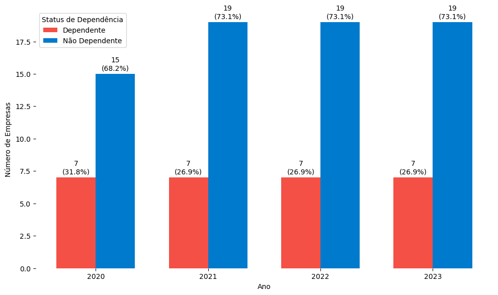

```python
# Filtrar o dataset para obter empresas localizadas no Distrito Federal (DF)
df_df = df[df["Estado"] == "DF"]

# Agrupar por 'Ano' e 'dep' (dependência) e contar o número de empresas
df_grouped = df_df.groupby(["Ano", "dep"]).size().reset_index(name="company_count")

# Criar um conjunto completo de combinações de ano e dependência
anos = df_grouped["Ano"].unique()
dependencias = ["Dependente", "Não Dependente"]

# Criar um conjunto completo de combinações de ano e dependência
complete_index = pd.MultiIndex.from_product([anos, dependencias], names=["Ano", "dep"])
df_complete = (
    df_grouped.set_index(["Ano", "dep"])
    .reindex(complete_index, fill_value=0)
    .reset_index()
)

# Calcular o total de empresas por ano
totais_anuais = df_complete.groupby("Ano")["company_count"].sum()

# Configuração da largura das barras
largura_barra = 0.35
fig, ax = plt.subplots(figsize=(10, 6))

# Posições para as barras
indice = np.arange(len(anos))

# Mapear as cores para diferentes dependências
cores = {"Dependente": "#F45046", "Não Dependente": "#007acc"}

# Plotar as barras para cada status de dependência
for i, dependencia in enumerate(dependencias):
    subset = df_complete[df_complete["dep"] == dependencia]
    barras = ax.bar(
        indice + i * largura_barra,
        subset["company_count"],
        largura_barra,
        label=dependencia,
        color=cores[dependencia],
    )

    # Adicionar os valores e porcentagens nas barras
    for j, barra in enumerate(barras):
        altura = barra.get_height()
        ano = subset.iloc[j]["Ano"]
        total_ano = totais_anuais[ano]
        porcentagem = (altura / total_ano) * 100 if total_ano > 0 else 0
        ax.annotate(
            f"{int(altura)}\n({porcentagem:.1f}%)",
            xy=(barra.get_x() + barra.get_width() / 2, altura),
            xytext=(0, 3),
            textcoords="offset points",
            ha="center",
            va="bottom",
        )

# Adicionar rótulos, título e legenda
ax.set_xlabel("Ano")
ax.set_ylabel("Número de Empresas")
ax.set_title("")
ax.set_xticks(indice + largura_barra / 2)
ax.set_xticklabels(anos)
ax.legend(title="Status de Dependência")

# Remover as bordas do gráfico
for spine in plt.gca().spines.values():
    spine.set_visible(False)

# Exibir o gráfico
plt.tight_layout()
plt.show()
```

#### Análise da Quantidade de Empresas Estatais por Setor no Distrito Federal

O setor de Habitação e Urbanização, representado por empresas como a CODHAB e a NOVACAP, manteve três empresas ativas durante todo o período analisado, evidenciando um foco constante em projetos habitacionais e urbanísticos. Outros setores, como Transporte e Saneamento, apresentam menor número de empresas, refletindo sua concentração em operadores-chave, como o Metrô/DF e a CAESB,respectivamente. Além disso, setores como Pesquisa e Assistência Técnica Agropecuária e Gestão de Ativos mantiveram estabilidade com apenas uma empresa cada, indicando especialização e foco em nichos específicos. Em contraste, o setor de Gás e Derivados permaneceu limitado, com apenas uma empresa, a CEBGÁS, ao longo dos anos, sugerindo potencial para expansão futura, dada a crescente relevância de combustíveis alternativos e infraestrutura de gás natural no Brasil.

De forma geral, o gráfico destaca uma estrutura relativamente estável de estatais por setor no DF, com variações pontuais, como o crescimento do setor energético. Essa estabilidade é reflexo do planejamento estratégico do governo, que prioriza setores com maior impacto socioeconômico, como energia, habitação e serviços financeiros. Essa análise pode subsidiar decisões sobre possíveis reestruturações ou expansões, com foco em maximizar a eficiência operacional e o impacto das estatais no desenvolvimento local.

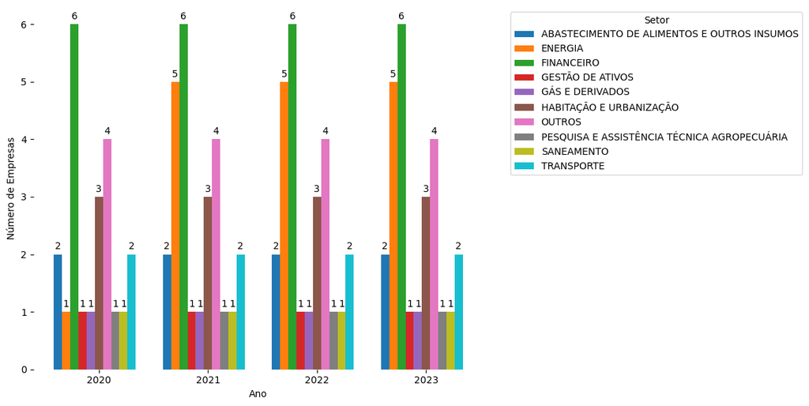

```python
# Filtrar o dataset para obter empresas localizadas no Distrito Federal (DF)
df_df = df[df["Estado"] == "DF"]

# Agrupar por 'Ano' e 'setor' e contar o número de empresas
df_grouped_setor = (
    df_df.groupby(["Ano", "setor"]).size().reset_index(name="company_count")
)

# Criar um conjunto completo de combinações de ano e setor
anos = df_grouped_setor["Ano"].unique()
setores = df_grouped_setor["setor"].unique()

# Criar um conjunto completo de combinações de ano e setor
complete_index = pd.MultiIndex.from_product([anos, setores], names=["Ano", "setor"])
df_complete_setor = (
    df_grouped_setor.set_index(["Ano", "setor"])
    .reindex(complete_index, fill_value=0)
    .reset_index()
)

# Configuração da largura das barras e redução do espaçamento entre os anos
largura_barra = 0.3  # Ajuste para manter as barras visíveis
fig, ax = plt.subplots(figsize=(12, 6))

# Posições para as barras com menor espaçamento entre os anos
# Reduzir o espaçamento para evitar excesso
indice = np.arange(len(anos)) * (len(setores) * 0.4)

# Plotar as barras para cada setor
for i, setor in enumerate(setores):
    subset = df_complete_setor[df_complete_setor["setor"] == setor]
    barras = ax.bar(
        indice + i * largura_barra, subset["company_count"], largura_barra, label=setor
    )

    # Adicionar os valores das empresas nas barras
    for barra in barras:
        altura = barra.get_height()
        ax.annotate(
            f"{int(altura)}",  # Mostrar o número inteiro
            xy=(barra.get_x() + barra.get_width() / 2, altura),
            xytext=(0, 3),  # Pequena margem acima da barra
            textcoords="offset points",
            ha="center",
            va="bottom",
        )

# Adicionar rótulos, título e legenda
ax.set_xlabel("Ano")
ax.set_ylabel("Número de Empresas")
ax.set_title("")

# Configurar espaçamento das barras entre os anos
ax.set_xticks(indice + (largura_barra * len(setores)) / 2)
ax.set_xticklabels(anos)

# Posicionar a legenda fora do gráfico
ax.legend(title="Setor", bbox_to_anchor=(1.05, 1), loc="upper left")

# Remover as bordas do gráfico
for spine in plt.gca().spines.values():
    spine.set_visible(False)

# Exibir o gráfico
plt.tight_layout()
plt.show()
```

### Como é a governança das empresas?

#### Quantitativo de Governança Corporativa nas Empresas Estatais do Distrito Federal em 2023

O gráfico abaixo ilustra o quantitativo de empresas estatais do Distrito Federal que adotaram diferentes estruturas de governança corporativa em 2023, destacando a presença de Conselhos de Administração, Conselhos Fiscais e Comitês de Auditoria. O destaque vai para o Conselho Fiscal, implementado em 96,2% das estatais (25 empresas), indicando um compromisso com a fiscalização contínua e a transparência das operações financeiras. Essa estrutura desempenha um papel central na supervisão da gestão financeira, reduzindo riscos de fraudes e desvios, além de assegurar que as práticas contábeis estejam em conformidade com as regulamentações aplicáveis.

Já o Conselho de Administração, presente em 84,6% das estatais (22 empresas), reforça a governança estratégica dessas organizações. Esse órgão é responsável por definir as diretrizes de longo prazo, avaliar o desempenho dos gestores e assegurar que as ações das empresas estejam alinhadas aos objetivos e metas estabelecidas pelo Governo do Distrito Federal. A ampla adoção do Conselho de Administração é um indicativo positivo de que a maioria das estatais busca equilibrar seus objetivos financeiros e sociais com práticas modernas de gestão corporativa.

Por outro lado, o Comitê de Auditoria, embora presente em apenas 38,5% das estatais (10 empresas), desempenha uma função crítica para o fortalecimento da governança. Esse comitê é responsável por garantir a integridade dos controles internos, monitorar os riscos corporativos e revisar relatórios financeiros com imparcialidade. A menor adoção desse órgão pode ser vista como uma oportunidade de melhoria, uma vez que o Comitê de Auditoria agrega valor à supervisão dos processos e aumenta a confiança de investidores e stakeholders no desempenho das estatais.

De maneira geral, o panorama apresentado pelo gráfico demonstra avanços significativos na governança corporativa das empresas estatais do DF. No entanto, há espaço para evolução, especialmente na ampliação da implementação de Comitês de Auditoria. Fortalecer as estruturas de governança com a adoção universal dessas práticas contribuirá para maior eficiência administrativa, mitigação de riscos e alinhamento às melhores práticas de mercado. O compromisso com a transparência e a accountability continuará sendo essencial para sustentar a confiança pública e garantir o cumprimento do papel estratégico das estatais no desenvolvimento do Distrito Federal.

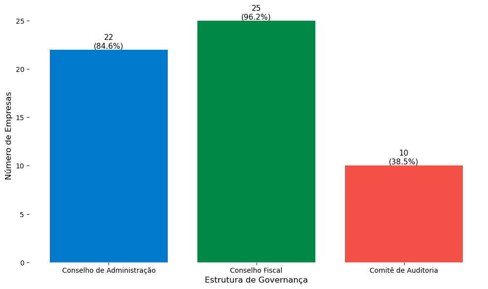

```python
# Filtrar os dados para o Estado DF e ano de 2023
df_filtrado = df[(df["Estado"] == "DF") & (df["Ano"] == 2023)]

# Contar o número de empresas para cada tipo de estrutura de governança
contagem_conselho_admin = df_filtrado["gov_ca"].str.upper().eq("SIM").sum()
contagem_conselho_fiscal = df_filtrado["gov_cf"].str.upper().eq("SIM").sum()
contagem_comite_auditoria = df_filtrado["gov_aud"].str.upper().eq("SIM").sum()

# Calcular o número total de empresas
total_empresas = len(df_filtrado)

# Criar um DataFrame com os dados de contagem
dados_contagem = pd.DataFrame(
    {
        "Estrutura de Governança": [
            "Conselho de Administração",
            "Conselho Fiscal",
            "Comitê de Auditoria",
        ],
        "Número de Empresas": [
            contagem_conselho_admin,
            contagem_conselho_fiscal,
            contagem_comite_auditoria,
        ],
    }
)

# Calcular a porcentagem de empresas para cada tipo de estrutura
dados_contagem["Porcentagem (%)"] = (
    dados_contagem["Número de Empresas"] / total_empresas
) * 100

# Criar o gráfico de barras com cores ajustadas
plt.figure(figsize=(10, 6))
plt.bar(
    dados_contagem["Estrutura de Governança"],
    dados_contagem["Número de Empresas"],
    color=["#007acc", "#008846", "#F45046"],
)

# Adicionar títulos e rótulos
plt.title("", fontsize=14)
plt.xlabel("Estrutura de Governança", fontsize=12)
plt.ylabel("Número de Empresas", fontsize=12)

# Mostrar o valor e a porcentagem sobre cada barra
for index, (quantidade, porcentagem) in enumerate(
    zip(dados_contagem["Número de Empresas"], dados_contagem["Porcentagem (%)"])
):
    plt.text(
        index,
        quantidade,
        f"{quantidade}\n({porcentagem:.1f}%)",
        ha="center",
        va="bottom",
        fontsize=11,
    )

# Remover as bordas do gráfico
for spine in plt.gca().spines.values():
    spine.set_visible(False)

plt.tight_layout()
plt.show()
```

#### Análise da Distribuição de Empresas por Combinação de Estruturas de Governança em 2023

A combinação mais robusta e instrumentos de governança, que inclui Conselho de Administração, Conselho Fiscal e Comitê de Auditoria (CA, CF, COAUD), foi adotada por 9 empresas. Essa configuração é considerada ideal, pois abrange os três pilares fundamentais da governança corporativa, permitindo maior controle interno, supervisão estratégica e mitigação de riscos financeiros. A implementação dessa estrutura demonstra maturidade em governança por parte dessas estatais, pois o Comitê de Auditoria desempenha um papel essencial ao revisar processos financeiros e monitorar a gestão de riscos, fortalecendo a confiança de stakeholders.

Outras configurações, como empresas que possuem apenas o Conselho Fiscal (CF) ou uma combinação de Conselho Fiscal e Comitê de Auditoria (CF, COAUD), foram menos recorrentes, representando 2 e 1 empresa, respectivamente. Notavelmente, apenas uma empresa não possui qualquer estrutura de governança registrada, o que é uma exceção preocupante, dado o potencial impacto dessa lacuna na supervisão e controle. Esse cenário sugere que, embora a maioria das empresas estatais tenha avançado na consolidação de suas estruturas de governança, ainda há espaço para melhorias, especialmente na ampliação da presença do Comitê de Auditoria, que agrega valor à gestão e à transparência.

O gráfico reflete a diversidade nas práticas de governança adotadas pelas estatais do DF, destacando avanços importantes na adoção de estruturas combinadas. Contudo, há oportunidades de aprimoramento, principalmente no fortalecimento das configurações mais completas, garantindo que todas as empresas tenham governança compatível com seu impacto estratégico e financeiro. A ampliação dessas práticas consolidará a credibilidade e a eficiência do setor público distrital.

```python
# Filtrar os dados para o Estado DF e ano de 2023
df_filtrado = df[(df["Estado"] == "DF") & (df["Ano"] == 2023)].copy()


# Definir uma função para categorizar as combinações de governança usando abreviações
def categorizar_combinacoes(row):
    ca = row["gov_ca"].upper() == "SIM"
    cf = row["gov_cf"].upper() == "SIM"
    aud = row["gov_aud"].upper() == "SIM"

    if ca and cf and aud:
        return "CA, CF, COAUD"
    elif ca and cf:
        return "CA, CF"
    elif ca and aud:
        return "CA, COAUD"
    elif cf and aud:
        return "CF, COAUD"
    elif ca:
        return "CA"
    elif cf:
        return "CF"
    elif aud:
        return "COAUD"
    else:
        return "Nenhum"


# Aplicar função de categorização
df_filtrado.loc[:, "Combinação"] = df_filtrado.apply(categorizar_combinacoes, axis=1)

# Contar números de empresas e agrupar por combinação, além de concatenar nomes das empresas
dados_contagem = (
    df_filtrado.groupby("Combinação")
    .agg({"emp": lambda x: "<br>".join(x), "Combinação": "size"})
    .rename(columns={"Combinação": "Número de Empresas", "emp": "Lista de Empresas"})
    .reset_index()
)

# Calcular a porcentagem de empresas para cada tipo de estrutura
dados_contagem["Porcentagem (%)"] = (
    dados_contagem["Número de Empresas"] / len(df_filtrado)
) * 100

# Criar gráfico interativo com plotly
fig = px.bar(
    dados_contagem,
    x="Combinação",
    y="Número de Empresas",
    text="Número de Empresas",
    labels={
        "Combinação": "Combinação de Estrutura de Governança",
        "Número de Empresas": "Número de Empresas",
    },
    hover_data={"Lista de Empresas": True, "Porcentagem (%)": True},
    title="",
)

# Atualizar template de hover para incluir empresas
fig.update_traces(
    hovertemplate=(
        "<b>Combinação:</b> %{x}<br>"
        "<b>Número de Empresas:</b> %{y}<br>"
        "<b>Empresas:</b> <br>%{customdata[0]}<br>"
        "<b>Porcentagem:</b> %{customdata[1]:.1f}%<extra></extra>"
    ),
    marker_color="#007acc",
    textposition="outside",
)

# Legenda explicativa pode ser adicionada abaixo
fig.add_annotation(
    x=0.99,
    y=1.05,
    xref="paper",
    yref="paper",
    text="Legenda: CA = Conselho de Administração, CF = Conselho Fiscal, COAUD = Comitê de Auditoria",
    font=dict(size=10, color="black", style="italic"),
    showarrow=False,
)

fig.update_layout(
    height=700,  # Aumenta a altura do gráfico
    xaxis_title="Combinação de Estrutura de Governança",
    yaxis_title="Número de Empresas",
    showlegend=False,
    plot_bgcolor="white",  # Define o fundo do gráfico como branco
    paper_bgcolor="white",  # Define o fundo do papel como branco
)

# Mostrar o gráfico
fig.show()
```

[output not shown]

#### Análise da Presença de Estruturas de Governança por Dependência em 2023

O gráfico abaixo compara a adoção de estruturas de governança entre as empresas estatais dependentes e não dependentes do Distrito Federal em 2023. Nota-se que todas as empresas dependentes (100%) possuem tanto Conselho de Administração (CA) quanto Conselho Fiscal (CF), enquanto entre as empresas não dependentes, a presença dessas estruturas é ligeiramente inferior: 78,9% possuem Conselho de Administração, e 94,7% contam com Conselho Fiscal. Esse cenário reflete uma preocupação em assegurar mecanismos mínimos de supervisão e estratégia para empresas que demandam recursos do governo, reforçando a necessidade de monitoramento rigoroso sobre o uso de verbas públicas.

A presença de Comitês de Auditoria (COAUD) é significativamente menor, especialmente entre as empresas dependentes, das quais apenas 14,3% (uma empresa) contam com essa estrutura, em contraste com 47,4% das empresas não dependentes (nove empresas). Essa discrepância pode indicar que as empresas dependentes, apesar de demandarem maior supervisão devido à sua dependência financeira, ainda não adotaram amplamente essa estrutura essencial para o monitoramento de riscos e auditoria independente. Por outro lado, a maior presença de Comitês de Auditoria entre empresas não dependentes pode estar associada à busca por maior eficiência e conformidade regulatória, já que essas organizações operam com maior autonomia financeira.

As vantagens da ampla adoção de Conselhos de Administração e Conselhos Fiscais residem na capacidade de supervisionar estrategicamente a gestão e monitorar as finanças das empresas. Para as estatais dependentes, esses órgãos garantem maior accountability e visibilidade no uso de recursos públicos, sendo essenciais para mitigar riscos de má gestão e desvios. Contudo, a ausência ou baixa adoção do Comitê de Auditoria, especialmente nas empresas dependentes, representa uma desvantagem significativa, pois limita a capacidade de identificar e corrigir problemas relacionados à gestão de riscos e conformidade financeira, elementos críticos para empresas que recebem aportes governamentais.

O panorama de governança apresentado reflete um bom nível de adesão às estruturas fundamentais, como os Conselhos de Administração e Fiscal, mas expõe lacunas no uso de ferramentas mais avançadas, como os Comitês de Auditoria. Para maximizar a eficiência e reduzir riscos, recomenda-se que as empresas dependentes priorizem a implementação de Comitês de Auditoria, reforçando sua capacidade de prestação de contas e assegurando a conformidade com as melhores práticas de governança corporativa. Esse fortalecimento é especialmente importante para empresas que recebem recursos do tesouro distrital, garantindo maior transparência e confiança da sociedade em sua gestão.

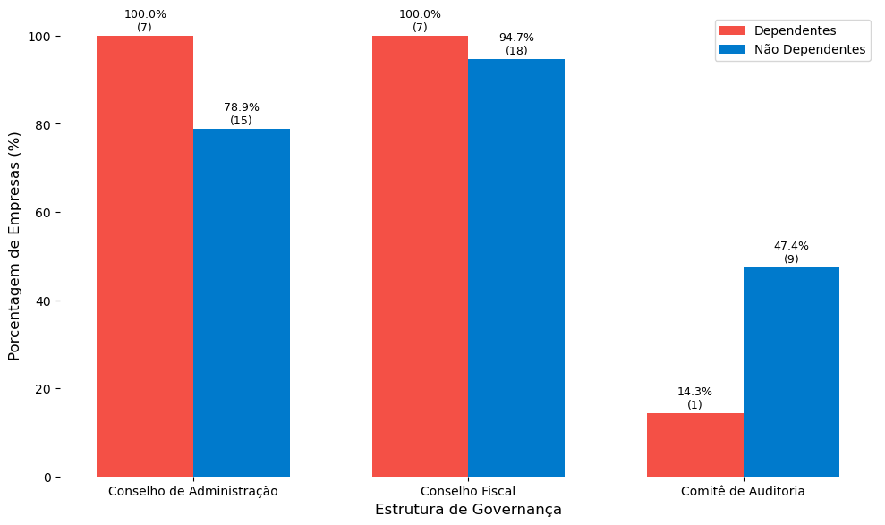

```python
# Filtrar os dados para o Estado DF e ano de 2023
df_filtrado = df[(df["Estado"] == "DF") & (df["Ano"] == 2023)]


# Função para contar e calcular porcentagens de empresas em relação à estrutura de governança
def contar_e_calcular_porcentagens(dep_status, total_empresas):
    ca_count = (
        df_filtrado[df_filtrado["dep"].str.upper() == dep_status]["gov_ca"]
        .str.upper()
        .eq("SIM")
        .sum()
    )
    cf_count = (
        df_filtrado[df_filtrado["dep"].str.upper() == dep_status]["gov_cf"]
        .str.upper()
        .eq("SIM")
        .sum()
    )
    aud_count = (
        df_filtrado[df_filtrado["dep"].str.upper() == dep_status]["gov_aud"]
        .str.upper()
        .eq("SIM")
        .sum()
    )
    return (
        (ca_count, ca_count / total_empresas * 100),
        (cf_count, cf_count / total_empresas * 100),
        (aud_count, aud_count / total_empresas * 100),
    )


# Calcular somatórios e porcentagens para empresas dependentes e não dependentes
total_dependentes = df_filtrado[df_filtrado["dep"].str.upper() == "DEPENDENTE"].shape[0]
total_nao_dependentes = df_filtrado[
    df_filtrado["dep"].str.upper() == "NÃO DEPENDENTE"
].shape[0]

dependentes_dados = contar_e_calcular_porcentagens("DEPENDENTE", total_dependentes)
nao_dependentes_dados = contar_e_calcular_porcentagens(
    "NÃO DEPENDENTE", total_nao_dependentes
)

# Dados para o gráfico
estruturas = ["Conselho de Administração", "Conselho Fiscal", "Comitê de Auditoria"]
indices = np.arange(len(estruturas))
largura = 0.35

# Criar o gráfico de barras agrupadas
plt.figure(figsize=(10, 6))

dependentes_valores = [x[1] for x in dependentes_dados]
nao_dependentes_valores = [x[1] for x in nao_dependentes_dados]

bars1 = plt.bar(
    indices - largura / 2,
    dependentes_valores,
    largura,
    label="Dependentes",
    color="#F45046",
)  # Azul
bars2 = plt.bar(
    indices + largura / 2,
    nao_dependentes_valores,
    largura,
    label="Não Dependentes",
    color="#007acc",
)  # Vermelho

# Adicionar títulos e rótulos
plt.title("", fontsize=14)
plt.xlabel("Estrutura de Governança", fontsize=12)
plt.ylabel("Porcentagem de Empresas (%)", fontsize=12)
plt.xticks(indices, estruturas)

# Adicionar legenda
plt.legend()

# Mostrar porcentagens e somatórios sobre cada barra
for i in range(len(estruturas)):
    dep_count, dep_percent = dependentes_dados[i]
    nao_dep_count, nao_dep_percent = nao_dependentes_dados[i]
    plt.text(
        i - largura / 2,
        dep_percent + 0.5,
        f"{dep_percent:.1f}%\n({dep_count})",
        ha="center",
        va="bottom",
        fontsize=9,
    )
    plt.text(
        i + largura / 2,
        nao_dep_percent + 0.5,
        f"{nao_dep_percent:.1f}%\n({nao_dep_count})",
        ha="center",
        va="bottom",
        fontsize=9,
    )

# Remover as bordas do gráfico
for spine in plt.gca().spines.values():
    spine.set_visible(False)

plt.tight_layout()
plt.show()
```

#### Análise da Rentabilidade Média das Empresas pela Combinação de Estruturas de Governança

O gráfico abaixo representa a rentabilidade média das empresas estatais distritais, calculada pela relação entre lucro e patrimônio líquido, considerando diferentes combinações de estruturas de governança em 2023. A combinação que inclui Conselho de Administração (CA), Conselho Fiscal (CF) e Comitê de Auditoria (COAUD) apresenta uma rentabilidade média de 17,5%, destacando-se como uma das mais robustas. Essa configuração promove maior supervisão estratégica e controle interno, elementos que contribuem significativamente para o desempenho financeiro positivo dessas empresas. A presença do Comitê de Auditoria nessa configuração é especialmente relevante, pois reforça a capacidade de identificar riscos e promover uma gestão eficiente.

Por outro lado, empresas que possuem apenas o Conselho Fiscal (CF) como estrutura de governança registraram a maior rentabilidade média, de 26,4%. Esse resultado pode refletir um foco direcionado em aspectos financeiros e contábeis, sem os custos e a complexidade de estruturas adicionais. No entanto, a ausência de um Conselho de Administração ou Comitê de Auditoria pode limitar o alinhamento estratégico e o monitoramento detalhado dos riscos de longo prazo. Isso sugere que, embora o desempenho financeiro imediato seja positivo, a sustentabilidade dessas empresas pode ser desafiada sem uma supervisão estratégica abrangente.

As empresas que adotaram apenas Conselho de Administração e Conselho Fiscal (CA, CF) apresentaram uma rentabilidade média de 3,0%, consideravelmente inferior às demais combinações. Essa configuração, embora suficiente para atender às exigências mínimas de governança, pode carecer de um nível mais profundo de análise e controle, especialmente nas áreas de auditoria e gestão de riscos. A ausência do Comitê de Auditoria, que proporciona maior detalhamento nos processos financeiros e operacionais, pode explicar o desempenho reduzido dessas empresas em comparação com as configurações mais completas.

Por fim, as empresas que não possuem qualquer estrutura de governança formal exibiram uma rentabilidade média negativa de -105,8%, refletindo severas dificuldades financeiras e de gestão. Essa ausência de governança formal é um fator crítico que impacta diretamente a sustentabilidade e a eficiência das operações. A falta de supervisão adequada impede o controle de riscos e compromete a capacidade de gerar resultados positivos. Essa situação destaca a importância de estruturas de governança bem implementadas como alicerces para o equilíbrio e o desempenho financeiro. Em síntese, o gráfico demonstra que a adoção de uma governança corporativa mais abrangente, com foco no alinhamento estratégico e no controle interno, é um elemento-chave para assegurar a rentabilidade das estatais distritais e sua contribuição sustentável para o desenvolvimento regional.

Observação: Instituto BRB e BRB Administradora e Corretora de Seguros não aparecem no gráfico pois possuem dados faltantes. Além disso, foram desconsideradas as empresas com patrimônio líquido negativo:

• CEBGAS - Companhia Brasiliense de Gás

• CODEPLAN - Companhia de Planejamento do Distrito Federal

• EMATER - Empresa de Assistência Técnica e Extensão Rural do Distrito Federal

• SAB - Sociedade de Abastecimento de Brasília

```python
import plotly.express as px
import pandas as pd

# Supondo que o DataFrame 'df' contenha as colunas necessárias
# Filtrar os dados apropriados: deve ser de 2023, estado DF, PL positivo e não nulo e lucros não nulos
df_2023 = df[
    (df["Ano"] == 2023) & (df["Estado"] == "DF") & (df["PL"] > 0) & df["lucros"].notna()
].copy()

# Calcular a rentabilidade individual
df_2023["rentabilidade"] = (df_2023["lucros"] / df_2023["PL"]) * 100


# Função de categorização de combinações de conselhos
def categorizar_combinacoes(row):
    ca = row["gov_ca"].strip().upper() == "SIM"
    cf = row["gov_cf"].strip().upper() == "SIM"
    aud = row["gov_aud"].strip().upper() == "SIM"

    if ca and cf and aud:
        return "CA, CF, COAUD"
    elif ca and cf:
        return "CA, CF"
    elif ca and aud:
        return "CA, COAUD"
    elif cf and aud:
        return "CF, COAUD"
    elif ca:
        return "CA"
    elif cf:
        return "CF"
    elif aud:
        return "COAUD"
    else:
        return "Nenhum"


# Aplicar categorização
df_2023["combinação"] = df_2023.apply(categorizar_combinacoes, axis=1)

# Agregar e preparar dados
df_agrupado = (
    df_2023.groupby("combinação")
    .agg(
        media_rentabilidade=("rentabilidade", "mean"),
        empresas=("emp", lambda x: "<br>".join(x)),
        detalhamento_rentabilidade=(
            "rentabilidade",
            lambda x: "<br>".join(map(lambda y: f"{y:.1f}%", x)),
        ),
    )
    .reset_index()
)

# Determinar a cor com base na rentabilidade média
df_agrupado["cor"] = df_agrupado["media_rentabilidade"].apply(
    lambda x: "#F46045" if x < 0 else "#007acc"
)

# Relação de combinações
todas_combinacoes = [
    "CA, CF, COAUD",
    "CA, CF",
    "CA, COAUD",
    "CF, COAUD",
    "CA",
    "CF",
    "COAUD",
    "Nenhum",
]
df_agrupado = (
    df_agrupado.set_index("combinação")
    .reindex(todas_combinacoes, fill_value=-1)
    .reset_index()
)
df_agrupado["cor"] = df_agrupado["media_rentabilidade"].apply(
    lambda x: "#F46045" if x < 0 else "#007acc"
)

# Certifique-se de ajustar o valor da barra 'Nenhum' para 0 para evitar possíveis confusões ao plotar com valores como -1
df_agrupado.loc[df_agrupado["media_rentabilidade"] == -1, "media_rentabilidade"] = 0

# Criação de gráfico interativo
fig = px.bar(
    df_agrupado,
    x="combinação",
    y="media_rentabilidade",
    text="media_rentabilidade",
    color="cor",  # Usa a coluna de cor que determinamos
    labels={
        "media_rentabilidade": "Rentabilidade Média (%)",
        "combinação": "Combinação de Conselhos",
    },
    hover_data={"empresas": True, "detalhamento_rentabilidade": True},
    title="",
)

# Atualizar template de hover
fig.update_traces(
    hovertemplate=(
        "<b>Combinação:</b> %{x}<br>"
        "<b>Rentabilidade Média:</b> %{y:.1f}%<br>"
        "<b>Empresas:</b> <br>%{customdata[0]}<br>"
        "<b>Rentabilidades:</b> <br>%{customdata[1]}<extra></extra>"
    ),
    texttemplate="%{text:.1f}%",  # Ajustar label de cada barra para porcentagem
    textposition="outside",
)

# Anotação informativa
fig.add_annotation(
    x=0.99,
    y=1.15,
    xref="paper",
    yref="paper",
    text="Legenda: CA = Conselho de Administração, CF = Conselho Fiscal, COAUD = Comitê de Auditoria",
    font=dict(size=10, color="black", style="italic"),
    showarrow=False,
)

# Ajustar layout final
fig.update_layout(
    height=500,
    xaxis_title="Combinação de Estrutura de Governança",
    yaxis_title="Rentabilidade Média (%)",
    showlegend=False,
    plot_bgcolor="white",  # Define o fundo do gráfico como branco
    paper_bgcolor="white",  # Define o fundo do papel como branco
)

# Exibir gráfico
fig.show()
```

[output not shown]

### Qual o resultado financeiro das estatais?

Entre 2020 e 2023, os resultados financeiros das empresas estatais do Distrito Federal evidenciaram oscilações relevantes, com predominância de empresas lucrativas em três dos quatro anos analisados, mas registrando períodos de piora em 2021 e 2023. Enquanto 2020 e 2022 foram marcados por maior proporção de resultados positivos, reflexo de esforços em eficiência operacional e recuperação econômica, 2021 destacou-se pelo aumento expressivo de prejuízos, particularmente nos setores de transporte público, saneamento e assistência técnica agropecuária. Esse desempenho negativo pode ser associado aos impactos prolongados da pandemia de COVID-19, que comprometeram a demanda por serviços, elevaram custos operacionais e atrasaram investimentos estratégicos, especialmente em setores dependentes de subsídios governamentais.

Em 2023, embora mais da metade das estatais tenham registrado lucro, houve um aumento na proporção de empresas deficitárias, refletindo desafios estruturais e custos crescentes em setores historicamente vulneráveis. Essa evolução demonstra que, além dos efeitos remanescentes da crise sanitária, fatores econômicos e setoriais, como pressão inflacionária e limitações regulatórias, continuam a impactar o desempenho financeiro. O comportamento financeiro ao longo do período reforça a necessidade de aprimorar a governança corporativa, analisar as causas estruturais de prejuízos e implementar estratégias voltadas à eficiência, garantindo a sustentabilidade das estatais, especialmente nas áreas mais expostas a pressões externas e dependentes de políticas públicas.

#### Distribuição anual das empresas em relação ao lucro ou prejuízo

##### Ano de 2023

O ano de 2023 apresentou uma leve piora em relação ao ano anterior, com 61,54% das estatais registrando lucro e 38,46% operando com prejuízo. Essa mudança sugere a existência de desafios persistentes, possivelmente relacionados a pressões macroeconômicas, aumento de custos operacionais e limitações no modelo de financiamento de empresas dependentes. Setores tradicionalmente deficitários continuam a impactar negativamente os resultados agregados, reforçando a importância de uma abordagem mais estruturada para equilibrar sustentabilidade financeira e a prestação de serviços essenciais.

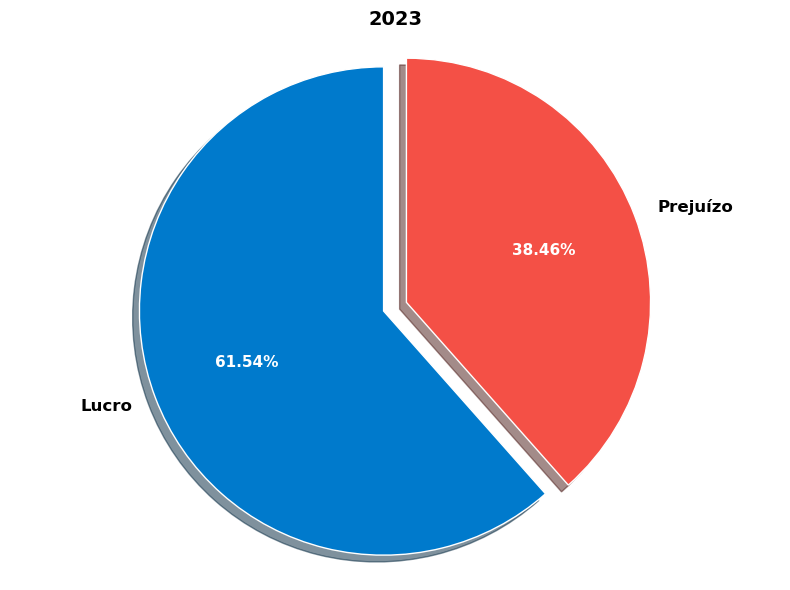

```python
# Filtrar o dataset para obter empresas localizadas no Distrito Federal (DF) para o ano de 2023
df_df = df[(df["Estado"] == "DF") & (df["Ano"] == 2023)].copy()

# Classificar as empresas como "Lucro" ou "Prejuízo"
df_df["Resultado"] = df_df["lucros"].apply(lambda x: "Lucro" if x > 0 else "Prejuízo")

# Contar a quantidade de empresas com lucro e prejuízo
df_resultado = df_df["Resultado"].value_counts().reset_index()
df_resultado.columns = ["Resultado", "Quantidade"]

# Definir cores mais suaves e explodir a fatia de "Prejuízo" para destaque
colors = ["#007acc", "#F45046"]  # Azul e vermelho
explode = (0, 0.1)  # Explodir a fatia de "Prejuízo" para destacar


def make_autopct():
    def my_autopct(pct):
        return f"{pct:.2f}%"

    return my_autopct


# Plotar gráfico de pizza com configurações personalizadas
plt.figure(figsize=(8, 6))
patches, texts, autotexts = plt.pie(
    df_resultado["Quantidade"],
    labels=df_resultado["Resultado"],
    autopct=make_autopct(),  # Apenas porcentagens
    colors=colors,
    explode=explode,
    shadow=True,
    startangle=90,
    wedgeprops={"edgecolor": "white"},
)

# Alterar estilo de texto das legendas para preto
for text in texts:
    text.set_color("black")
    text.set_fontsize(12)
    text.set_weight("bold")

# Alterar estilo de texto das porcentagens para branco e negrito
for autotext in autotexts:
    autotext.set_color("white")
    autotext.set_fontsize(11)
    autotext.set_weight("bold")

# Adicionar título com estilo mais profissional
plt.title(
    "2023",
    fontsize=14,
    weight="bold",
)

# Garantir que o gráfico seja circular
plt.axis("equal")

# Exibir o gráfico
plt.tight_layout()
plt.show()
```

##### Ano de 2022

Em 2022, houve uma recuperação significativa no desempenho financeiro das estatais, com 69,23% das empresas apresentando lucro e apenas 30,77% registrando prejuízo. Esse aumento na proporção de empresas lucrativas pode ser atribuído a uma recuperação econômica mais ampla, combinada com esforços para melhorar a eficiência operacional e a governança das estatais. O desempenho positivo de setores estratégicos, como financeiro e energia, foi crucial para esse resultado. Este período reflete o impacto de políticas públicas e ajustes internos que permitiram maior estabilidade financeira.

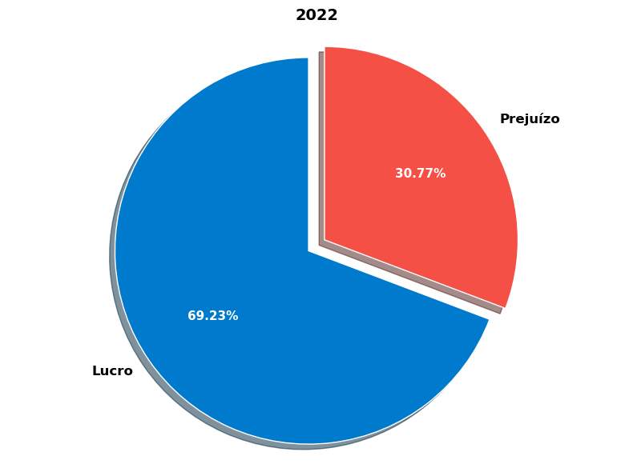

```python
# Filtrar o dataset para obter empresas localizadas no Distrito Federal (DF) para o ano de 2022
df_2022 = df[(df["Estado"] == "DF") & (df["Ano"] == 2022)].copy()

# Verificar se há dados para processar
if len(df_2022) == 0:
    print("Não há dados de empresas para o DF no ano de 2022.")
else:
    # Classificar as empresas como "Lucro" ou "Prejuízo"
    df_2022["Resultado"] = df_2022["lucros"].apply(
        lambda x: "Lucro" if x > 0 else "Prejuízo"
    )

    # Contar a quantidade de empresas com lucro e prejuízo
    df_resultado_2022 = df_2022["Resultado"].value_counts().reset_index()
    df_resultado_2022.columns = ["Resultado", "Quantidade"]

    # Definir cores mais suaves e explodir a fatia de "Prejuízo" para destaque
    colors = ["#007acc", "#F45046"]  # Azul e vermelho
    explode = (0, 0.1)  # Explodir a fatia de "Prejuízo" para destacar

    def make_autopct():
        def my_autopct(pct):
            return f"{pct:.2f}%"

        return my_autopct

    # Plotar gráfico de pizza com configurações personalizadas
    plt.figure(figsize=(8, 6))
    patches, texts, autotexts = plt.pie(
        df_resultado_2022["Quantidade"],
        labels=df_resultado_2022["Resultado"],
        autopct=make_autopct(),
        colors=colors,
        explode=explode,
        shadow=True,
        startangle=90,
        wedgeprops={"edgecolor": "white"},
    )

    # Alterar estilo de texto das legendas para preto
    for text in texts:
        text.set_color("black")
        text.set_fontsize(12)
        text.set_weight("bold")

    # Alterar estilo de texto das porcentagens para branco e negrito
    for autotext in autotexts:
        autotext.set_color("white")
        autotext.set_fontsize(11)
        autotext.set_weight("bold")

    # Adicionar título com estilo mais profissional
    plt.title(
        "2022",
        fontsize=14,
        weight="bold",
    )

    # Garantir que o gráfico seja circular
    plt.axis("equal")

    # Exibir o gráfico
    plt.tight_layout()
    plt.show()
```

##### Ano de 2021

O ano de 2021 trouxe uma inversão preocupante no panorama, com 57,69% das estatais apresentando prejuízo, enquanto apenas 42,31% registraram lucro. Essa mudança pode estar relacionada aos impactos prolongados da pandemia e à recuperação econômica ainda lenta em setores-chave. Empresas dependentes de subsídios governamentais, como transporte público e assistência técnica agropecuária, enfrentaram maior pressão financeira. Este ano destacou a importância de estratégias de mitigação de riscos e revisão de modelos operacionais para melhorar a sustentabilidade das operações.

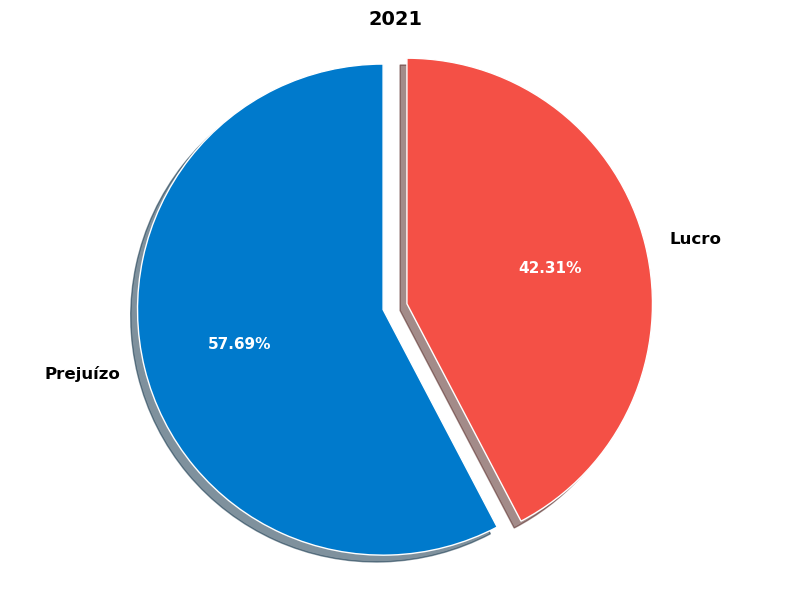

```python
# Filtrar o dataset para obter empresas localizadas no Distrito Federal (DF) para o ano de 2021
df_2021 = df[(df["Estado"] == "DF") & (df["Ano"] == 2021)].copy()

# Verificar se há dados para processar
if len(df_2021) == 0:
    print("Não há dados de empresas para o DF no ano de 2021.")
else:
    # Classificar as empresas como "Lucro" ou "Prejuízo"
    df_2021["Resultado"] = df_2021["lucros"].apply(
        lambda x: "Lucro" if x > 0 else "Prejuízo"
    )

    # Contar a quantidade de empresas com lucro e prejuízo
    df_resultado_2021 = df_2021["Resultado"].value_counts().reset_index()
    df_resultado_2021.columns = ["Resultado", "Quantidade"]

    # Definir cores mais suaves e explodir a fatia de "Prejuízo" para destaque
    colors = ["#007acc", "#F45046"]  # Azul e vermelho
    explode = (0, 0.1)  # Explodir a fatia de "Prejuízo" para destacar

    def make_autopct():
        def my_autopct(pct):
            return f"{pct:.2f}%"

        return my_autopct

    # Plotar gráfico de pizza com configurações personalizadas
    plt.figure(figsize=(8, 6))
    patches, texts, autotexts = plt.pie(
        df_resultado_2021["Quantidade"],
        labels=df_resultado_2021["Resultado"],
        autopct=make_autopct(),
        colors=colors,
        explode=explode,
        shadow=True,
        startangle=90,
        wedgeprops={"edgecolor": "white"},
    )

    # Alterar estilo de texto das legendas para preto
    for text in texts:
        text.set_color("black")
        text.set_fontsize(12)
        text.set_weight("bold")

    # Alterar estilo de texto das porcentagens para branco e negrito
    for autotext in autotexts:
        autotext.set_color("white")
        autotext.set_fontsize(11)
        autotext.set_weight("bold")

    # Adicionar título com estilo mais profissional
    plt.title(
        "2021",
        fontsize=14,
        weight="bold",
    )

    # Garantir que o gráfico seja circular
    plt.axis("equal")

    # Exibir o gráfico
    plt.tight_layout()
    plt.show()
```

##### Ano de 2020

No ano de 2020, 63,64% das empresas registraram lucro, enquanto 36,36% operaram com prejuízo. Esse resultado reflete um equilíbrio financeiro, com a maioria das estatais apresentando resultados positivos, mesmo diante do impacto inicial da pandemia de COVID-19. Esse cenário pode ser explicado pelo desempenho robusto de setores como financeiro e imobiliário, que se destacaram pela resiliência em meio às incertezas econômicas. Entretanto, os resultados deficitários de uma parcela das empresas sugerem a necessidade de atenção em setores mais vulneráveis, como transporte e saneamento.

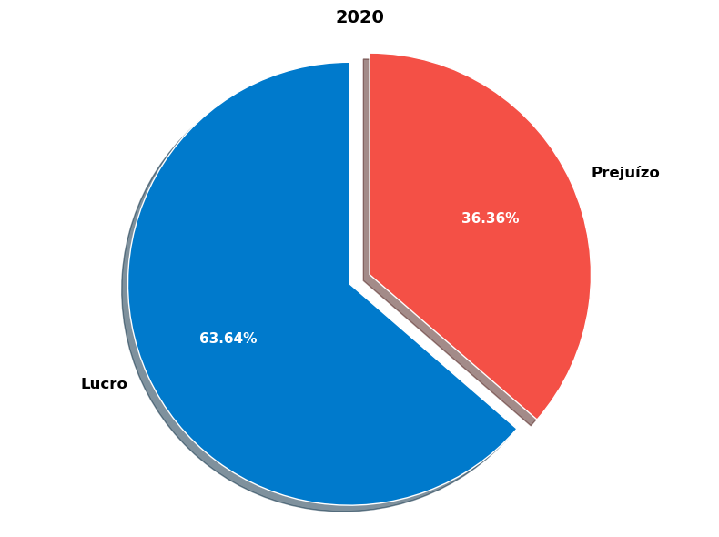

```python
# Filtrar o dataset para obter empresas localizadas no Distrito Federal (DF) para o ano de 2020
df_2020 = df[(df["Estado"] == "DF") & (df["Ano"] == 2020)].copy()

# Verificar se há dados para processar
if len(df_2020) == 0:
    print("Não há dados de empresas para o DF no ano de 2020.")
else:
    # Classificar as empresas como "Lucro" ou "Prejuízo"
    df_2020["Resultado"] = df_2020["lucros"].apply(
        lambda x: "Lucro" if x > 0 else "Prejuízo"
    )

    # Contar a quantidade de empresas com lucro e prejuízo
    df_resultado_2020 = df_2020["Resultado"].value_counts().reset_index()
    df_resultado_2020.columns = ["Resultado", "Quantidade"]

    # Definir cores mais suaves e explodir a fatia de "Prejuízo" para destaque
    colors = ["#007acc", "#F45046"]  # Azul e vermelho
    explode = (0, 0.1)  # Explodir a fatia de "Prejuízo" para destacar

    def make_autopct():
        def my_autopct(pct):
            return f"{pct:.2f}%"

        return my_autopct

    # Plotar gráfico de pizza com configurações personalizadas
    plt.figure(figsize=(8, 6))
    patches, texts, autotexts = plt.pie(
        df_resultado_2020["Quantidade"],
        labels=df_resultado_2020["Resultado"],
        autopct=make_autopct(),
        colors=colors,
        explode=explode,
        shadow=True,
        startangle=90,
        wedgeprops={"edgecolor": "white"},
    )

    # Alterar estilo de texto das legendas para preto
    for text in texts:
        text.set_color("black")
        text.set_fontsize(12)
        text.set_weight("bold")

    # Alterar estilo de texto das porcentagens para branco e negrito
    for autotext in autotexts:
        autotext.set_color("white")
        autotext.set_fontsize(11)
        autotext.set_weight("bold")

    # Adicionar título com estilo mais profissional
    plt.title(
        "2020",
        fontsize=14,
        weight="bold",
    )

    # Garantir que o gráfico seja circular
    plt.axis("equal")

    # Exibir o gráfico
    plt.tight_layout()
    plt.show()
```

#### Lucros e Prejuízos acumulados de 2020 a 2023 por setor de atuação

O gráfico abaixo evidencia os lucros e prejuízos acumulados pelas empresas estatais do Distrito Federal entre 2020 e 2023, distribuídos por setor de atuação. O setor financeiro destacou-se como o mais lucrativo no período, acumulando R$ 3,02 bilhões, impulsionado pelo desempenho consistente do BRB e suas subsidiárias, que se beneficiaram de uma diversificação estratégica de serviços bancários, seguros e investimentos. Este resultado reflete a solidez do setor em termos de geração de receitas e controle de custos, consolidando sua importância no equilíbrio econômico das estatais distritais.

Os setores de habitação e urbanização, energia e saneamento também apresentaram desempenhos financeiros positivos, acumulando R$ 2,17 bilhões, R$ 1,5 bilhão e R$ 1,04 bilhão, respectivamente. O setor de habitação e urbanização, liderado por empresas como a TERRACAP e a CODHAB, obteve resultados sólidos devido à valorização de ativos imobiliários e à execução de projetos habitacionais estratégicos. O setor energético, por sua vez, beneficiou-se da reorganização e diversificação das operações da CEB, com foco em geração, distribuição e iluminação pública. No setor de saneamento, a CAESB foi determinante para a manutenção de um resultado positivo, apesar dos desafios operacionais inerentes à prestação de serviços essenciais.

Em contraste, os setores de transporte e pesquisa e assistência técnica agropecuária acumularam prejuízos significativos, totalizando R$ -345,3 milhões e R$ -59,8 milhões, respectivamente. O desempenho negativo do setor de transporte, liderado pelo Metrô/DF, reflete desafios estruturais como a dependência de subsídios, aumento de custos operacionais e limitações na ampliação de receitas.

Da mesma forma, o setor agropecuário, representado pela EMATER, apresentou prejuízos devido a dificuldades no financiamento de suas operações e na captação de recursos para projetos de assistência técnica rural. Esses resultados negativos ressaltam a necessidade de intervenções estratégicas nesses setores, com foco na melhoria da eficiência operacional e na revisão de modelos de financiamento para garantir maior sustentabilidade financeira a longo prazo.

```python
# Filtrar o dataset para obter empresas localizadas no Distrito Federal (DF)
df = df[df["Estado"] == "DF"].copy()

# Limpar os nomes dos setores: remover espaços extras e padronizar
df["setor"] = df["setor"].str.strip().str.upper()

# Agrupar por setor e calcular o total de lucros (positivos e negativos)
df_grouped_setor = (
    df.groupby("setor")
    .agg(
        lucros_totais=("lucros", "sum"),
        empresas=("emp", lambda x: "<br>".join(x.astype(str))),
    )
    .reset_index()
)

# Classificar setores com lucro ou prejuízo
df_grouped_setor["Resultado"] = df_grouped_setor["lucros_totais"].apply(
    lambda x: "Lucro" if x > 0 else "Prejuízo"
)

# Ordenar os dados do maior para o menor lucro
df_grouped_setor = df_grouped_setor.sort_values(by="lucros_totais", ascending=False)

# Ajustar nomes de setores longos dividindo em palavras para melhorar legibilidade
df_grouped_setor["setor"] = df_grouped_setor["setor"].apply(
    lambda x: "<br>".join(x.split())
)

# Criar gráfico de barras com Plotly
fig = px.bar(
    df_grouped_setor,
    x="setor",
    y="lucros_totais",
    text=df_grouped_setor["lucros_totais"].apply(lambda x: f"R$ {x:,.0f}"),
    hover_data={"empresas": True},
    color="Resultado",
    color_discrete_map={"Lucro": "#007acc", "Prejuízo": "#F45046"},
    labels={
        "lucros_totais": "Lucros/Prejuízos Totais (R$)",
        "setor": "Setor de Atuação",
    },
    title="",
)

# Atualizar layout das barras
fig.update_traces(
    hovertemplate=(
        "<b>Setor:</b> %{x}<br>"
        "<b>Lucros Totais:</b> %{y:,.2f}<br>"
        "<b>Empresas:</b> <br>%{customdata}<extra></extra>"
    ),
    textposition="outside",
)

# Ajustar layout geral do gráfico
fig.update_layout(
    xaxis_title="Setor de Atuação",
    yaxis_title="Lucros/Prejuízos Totais (R$)",
    showlegend=False,
    height=600,
    title_x=0.5,  # Centralizar o título
    plot_bgcolor="white",  # Define o fundo do gráfico como branco
    paper_bgcolor="white",  # Define o fundo do papel como branco
)

# Mostrar o gráfico
fig.show()
```

[output not shown]

#### Relação entre Lucro ou Prejuízo e o Patrimônio Líquido em 2023

O gráfico abaixo demonstra a relação entre o lucro ou prejuízo das empresas estatais do Distrito Federal e seus respectivos patrimônios líquidos em 2023. Essa análise é essencial para avaliar a eficiência das empresas em gerar resultados financeiros positivos a partir de seus recursos patrimoniais. Empresas com maior patrimônio líquido tendem a ter maior capacidade de alavancagem operacional e financeira, o que deveria, em teoria, traduzir-se em lucros consistentes. No entanto, os resultados apresentados revelam uma diversidade significativa de desempenhos, com algumas empresas altamente lucrativas e outras registrando prejuízos, independentemente do tamanho de seus patrimônios.

Observa-se que as empresas com patrimônios líquidos elevados, representadas por pontos no extremo direito do gráfico, em sua maioria apresentam lucros consistentes. Este é o caso de empresas do setor financeiro e energético, que, devido à natureza de suas operações e à estrutura de governança robusta, conseguem maximizar a eficiência no uso de seus recursos patrimoniais. A relação positiva entre patrimônio líquido e lucro nessas empresas reforça a importância de uma gestão estratégica orientada para resultados, com foco na otimização de receitas e controle de custos.

Por outro lado, é preocupante notar a presença de empresas com patrimônio líquido reduzido e prejuízos recorrentes, marcadas por pontos no quadrante inferior esquerdo do gráfico. Esses casos, muitas vezes associados a setores como transporte público e assistência técnica agropecuária, evidenciam desafios estruturais significativos. As limitações na geração de receitas próprias, aliadas a custos operacionais elevados e dependência de subsídios governamentais, dificultam a sustentabilidade financeira dessas organizações. Além disso, a gestão de empresas com patrimônios líquidos negativos merece atenção especial, pois representa um risco fiscal para o Governo do Distrito Federal, sendo necessário avaliar medidas de reestruturação e melhoria operacional.

A análise reforça a importância de uma governança corporativa sólida e de estratégias diferenciadas para setores mais vulneráveis. A implementação de práticas de gestão eficientes, associada ao controle rigoroso dos custos e à diversificação de receitas, é essencial para alinhar o desempenho financeiro das empresas ao potencial representado por seus patrimônios líquidos. Em última análise, o gráfico destaca a necessidade de intervenções estratégicas em empresas deficitárias, com foco em garantir a sustentabilidade a longo prazo e a contribuição positiva para o desenvolvimento do Distrito Federal.

```python
# Filtrar o dataset e garantir a ordem correta dos dados
df_filtered = df[(df["Estado"] == "DF") & (df["Ano"] == 2023)].copy()

# Verificar a consistência removendo nulos e resetando o índice
df_filtered_clean = df_filtered.dropna(subset=["lucros", "PL"]).reset_index(drop=True)

# Criar o gráfico de dispersão interativo
fig = px.scatter(
    df_filtered_clean,
    x="PL",
    y="lucros",
    color=df_filtered_clean["lucros"].apply(
        lambda lucro: "Lucro" if lucro > 0 else "Prejuízo"
    ),
    labels={
        "PL": "Patrimônio Líquido (R$)",
        "lucros": "Lucro/Prejuízo (R$)",
        "color": "",  # Remover o texto "color" do label
    },
    color_discrete_map={
        "Lucro": "#007acc",
        "Prejuízo": "#F45046",
    },  # Definir cores para lucro e prejuízo
    hover_name="emp",  # Define a coluna a usar para o nome no hover
)

# Configurar hovertemplate para garantir formatação correta
fig.update_traces(
    hovertemplate=(
        "<b>%{hovertext}</b><br>"
        "Patrimônio Líquido: R$ %{x:,.2f}<br>"
        "Lucro/Prejuízo: R$ %{y:,.2f}<extra></extra>"
    )
)

# Atualizar layout
fig.update_layout(
    xaxis_title="Patrimônio Líquido (R$)",
    yaxis_title="Lucro/Prejuízo (R$)",
    title=dict(text="", x=0.5),
    legend_title_text="",  # Remove o título "Color" da legenda
    plot_bgcolor="white",  # Define o fundo do gráfico como branco
    paper_bgcolor="white",  # Define o fundo do papel como branco
)

# Adicionar linha de referência no eixo Y=0
fig.add_hline(y=0, line_dash="dash", line_color="black")

# Exibir o gráfico
fig.show()
```

[output not shown]

#### Rentabilidade das empresas em 2023 - (Lucro ou Prejuízo / Patrimônio Líquido)

O gráfico abaixo evidencia a rentabilidade das empresas estatais do Distrito Federal em 2023, medida pela relação entre lucro ou prejuízo e patrimônio líquido. Empresas como CEB Participações, CEB Lajeado e CAESB destacaram-se com as maiores rentabilidades, demonstrando eficiência na utilização de seus ativos para gerar retornos financeiros positivos. Esses resultados refletem estratégias de gestão sólidas, otimização de processos operacionais e modelos de negócios ajustados à demanda do mercado. O destaque do setor energético e do saneamento reforça o impacto de serviços essenciais com forte capacidade de geração de receitas, mesmo em um cenário econômico desafiador.

No entanto, o gráfico também expõe pontos críticos relacionados a empresas com rentabilidade negativa, como a DF Gestão de Ativos, que apresentou o desempenho mais preocupante, com valores muito abaixo do esperado. Essa baixa rentabilidade pode ser atribuída a uma combinação de desafios estruturais, falta de estratégias claras de geração de receita e possível subutilização de ativos. Outras empresas com resultados negativos incluem a CODHAB, o Metrô/DF e a CEB Iluminação Pública e Serviços, setores historicamente desafiadores, dada sua dependência de subsídios governamentais e altos custos operacionais. Esses desempenhos deficitários destacam a necessidade de reavaliações estratégicas, redução de ineficiências e implementação de melhorias na gestão.

A análise geral revela um panorama de contraste entre empresas altamente rentáveis e aquelas em dificuldades financeiras, reforçando a necessidade de políticas diferenciadas para cada caso. Empresas com bom desempenho devem continuar investindo na ampliação de suas operações e inovação, enquanto aquelas com rentabilidade negativa requerem intervenções específicas, como reestruturação, diversificação de receitas e maior eficiência nos custos operacionais. Esses ajustes são essenciais para garantir a sustentabilidade e o impacto positivo das estatais no desenvolvimento econômico e social do Distrito Federal.

Alguns pontos adicionais que complementam a análise sistêmica das empresas:

I. Disparidade na Rentabilidade: O gráfico mostra uma disparidade acentuada entre empresas com alta rentabilidade e aquelas com resultados negativos. Essa diferença destaca a necessidade de aprofundar a análise das políticas setoriais e dos modelos de gestão. Empresas de setores essenciais, como transporte e habitação, muitas vezes operam com foco em atender políticas públicas, o que pode impactar negativamente sua rentabilidade, mas reforça sua relevância social. Esse trade-off entre sustentabilidade financeira e impacto social deve ser avaliado de forma integrada.

II. Impacto Setorial e Subsídios: Empresas de setores como transporte e habitação (e.g., Metrô/DF, CODHAB) enfrentam desafios estruturais decorrentes de sua dependência de subsídios governamentais e pressão para manter tarifas acessíveis. Essa condição pode justificar parcialmente os resultados negativos, mas reforça a necessidade de buscar alternativas sustentáveis, como parcerias público-privadas (PPPs), modernização tecnológica e revisão de custos operacionais.

III. Governança e Impacto nos Resultados: Um ponto que merece destaque é o papel da governança corporativa na determinação desses resultados. Empresas com estrutura de governança mais robusta tendem a apresentar maior capacidade de adaptação às pressões econômicas e regulatórias, o que pode explicar o desempenho positivo de algumas estatais, como as do setor energético. Investir no fortalecimento da governança, especialmente nas empresas deficitárias, pode ser uma estratégia para melhorar seus resultados financeiros.

Instituto BRB e BRB Administradora e Corretora de Seguros não aparecem no gráfico pois possuem dados faltantes. Além disso, foram desconsideradas as empresas com patrimônio líquido negativo:

CEBGAS - Companhia Brasiliense de Gás

CODEPLAN - Companhia de Planejamento do Distrito Federal

EMATER - Empresa de Assistência Técnica e Extensão Rural do Distrito Federal

SAB - Sociedade de Abastecimento de Brasília

```python
# Filtrar o dataframe para incluir apenas o Estado DF e Ano 2023
df_filtered = df[(df["Estado"] == "DF") & (df["Ano"] == 2023)].copy()

# Remover linhas com valores NaN nas colunas necessárias e PL negativo
df_filtered = df_filtered.dropna(subset=["lucros", "PL"])
df_filtered = df_filtered[df_filtered["PL"] >= 0]  # Remover empresas com PL negativo

# Calcular Rentabilidade (%)
df_filtered["Rentabilidade (%)"] = (df_filtered["lucros"] / df_filtered["PL"]) * 100

# Adicionar uma coluna auxiliar para as cores
df_filtered["color"] = df_filtered["Rentabilidade (%)"].apply(
    lambda x: "#F45046" if x < 0 else "#007acc"
)

# Ordenar o dataframe do maior para o menor rentabilidade
df_filtered.sort_values(by="Rentabilidade (%)", ascending=True, inplace=True)

# Criação do gráfico de barras
fig = px.bar(
    df_filtered,
    x="Rentabilidade (%)",
    y="emp",
    orientation="h",
    hover_data={"Rentabilidade (%)": ":.2f", "lucros": ":.2f", "PL": ":.2f"},
    labels={"emp": "Empresa", "Rentabilidade (%)": "Rentabilidade (%)"},
    title="",
)

# Atualizar a cor das barras conforme a condição
fig.update_traces(marker_color=df_filtered["color"])

# Formatando o hovertext para exibir valores de lucros e PL com separadores de milhar
fig.update_traces(
    hovertemplate=(
        "<b>%{y}</b><br>Rentabilidade: %{x:.2f}%<br>"
        "Lucros: R$%{customdata[0]:,.2f}<br>"
        "PL: R$%{customdata[1]:,.2f}<extra></extra>"
    )
)

fig.update_layout(
    height=1000,
    plot_bgcolor="white",  # Define o fundo do gráfico como branco
    paper_bgcolor="white",  # Define o fundo do papel como branco
)  # Aumenta a altura do gráfico

# Exibir o gráfico
fig.show()
```

#### Rentabilidade média das empresas por setor em 2023 (Lucro ou Prejuízo / Patrimônio Líquido)

O gráfico abaixo, de rentabilidade média das empresas estatais do Distrito Federal em 2023, por setor, reflete a eficiência na utilização do patrimônio líquido para gerar resultados financeiros positivos ou negativos. Os setores de saneamento, energia e financeiro destacaram-se positivamente, apresentando os melhores índices de rentabilidade média. O setor de saneamento, liderado pela CAESB, alcançou o topo do ranking, evidenciando a robustez da gestão operacional e a relevância estratégica de serviços essenciais bem estruturados. Já os setores de energia e financeiro, com destaque para o grupo CEB e o BRB, respectivamente, demonstraram grande capacidade de geração de receita em contextos econômicos desafiadores, reforçando a maturidade na gestão dos ativos e a diversificação dos modelos de negócio.

Por outro lado, o setor de gestão de ativos registrou o pior desempenho, com uma rentabilidade média extremamente negativa. Essa situação pode ser atribuída a desafios estruturais e operacionais enfrentados pela DF Gestão de Ativos, que sofre com a baixa utilização de seu patrimônio e modelos de negócios ineficazes. O desempenho negativo desse setor é um alerta para a necessidade de reestruturação e estratégias voltadas à valorização e melhor uso dos ativos administrados, buscando reverter prejuízos e aumentar a sustentabilidade financeira.

Os setores de habitação e urbanização, transporte e abastecimento de alimentos também apresentaram resultados negativos, mas em menor magnitude quando comparados ao setor de gestão de ativos. A CODHAB e o Metrô/DF, líderes nesses setores, operam em áreas altamente dependentes de subsídios governamentais, enfrentando dificuldades para alinhar a prestação de serviços sociais às exigências de rentabilidade financeira. Esses resultados sugerem a necessidade de políticas públicas e intervenções estratégicas que equilibrem o impacto social e a eficiência financeira, garantindo a continuidade e melhoria dos serviços essenciais para a população.

Em síntese, a análise de rentabilidade média por setor em 2023 evidencia disparidades significativas no desempenho das estatais distritais, reforçando a importância de estratégias específicas para cada setor. Setores lucrativos devem continuar investindo em inovação e expansão, enquanto setores deficitários necessitam de reformas estruturais e melhorias na governança para superar os desafios financeiros e operacionais. Essa abordagem permitirá maior equilíbrio entre a sustentabilidade financeira das empresas e seu papel estratégico no desenvolvimento econômico e social do Distrito Federal.

Instituto BRB e BRB Administradora e Corretora de Seguros não aparecem no gráfico pois possuem dados faltantes. Além disso, foram desconsideradas as empresas com patrimônio líquido negativo:

CEBGAS - Companhia Brasiliense de Gás

CODEPLAN - Companhia de Planejamento do Distrito Federal

EMATER - Empresa de Assistência Técnica e Extensão Rural do Distrito Federal

SAB - Sociedade de Abastecimento de Brasília

```python
# Filtrar o dataframe para incluir apenas o Estado DF e Ano 2023
df_filtered = df[(df["Estado"] == "DF") & (df["Ano"] == 2023)].copy()

# Remover linhas com valores NaN nas colunas necessárias e desconsiderar PL negativo
df_filtered = df_filtered.dropna(subset=["lucros", "PL", "setor", "emp"])
df_filtered = df_filtered[df_filtered["PL"] >= 0]  # Excluir empresas com PL negativo

# Calcular Rentabilidade (%)
df_filtered["Rentabilidade (%)"] = (df_filtered["lucros"] / df_filtered["PL"]) * 100

# Agrupar por setor e calcular a média de rentabilidade e compilar a lista de empresas
df_grouped = (
    df_filtered.groupby("setor")
    .agg(
        Rentabilidade_medio=("Rentabilidade (%)", "mean"),
        Lucros_total=("lucros", "sum"),
        PL_total=("PL", "sum"),
        empresas=("emp", lambda x: ", ".join(x)),
    )
    .reset_index()
)

# Adicionar uma coluna auxiliar para as cores com base em rentabilidade média
df_grouped["color"] = df_grouped["Rentabilidade_medio"].apply(
    lambda x: "#F45046" if x < 0 else "#007acc"
)

# Ordenar o dataframe do maior para o menor média de rentabilidade
df_grouped.sort_values(by="Rentabilidade_medio", ascending=True, inplace=True)

# Criação do gráfico de barras por setor
fig = px.bar(
    df_grouped,
    x="Rentabilidade_medio",
    y="setor",
    orientation="h",
    hover_data={
        "Rentabilidade_medio": ":.2f",
        "Lucros_total": ":.2f",
        "PL_total": ":.2f",
    },
    labels={"setor": "Setor", "Rentabilidade_medio": "Rentabilidade Média (%)"},
    title="",
)

# Atualizar a cor das barras conforme a condição
fig.update_traces(marker_color=df_grouped["color"])

# Formatando o hovertext para exibir valores e a lista de empresas
fig.update_traces(
    hovertemplate=(
        "<b>%{y}</b><br>Empresas: %{customdata[2]}<br>Rentabilidade Média: %{x:.2f}%<br>"
        "Lucros Totais: R$%{customdata[0]:,.2f}<br>"
        "PL Total: R$%{customdata[1]:,.2f}<extra></extra>"
    ),
    customdata=df_grouped[
        ["Lucros_total", "PL_total", "empresas"]
    ],  # Incluir 'empresas' para hover
)

fig.update_layout(
    height=400,  # Ajusta a altura do gráfico
    plot_bgcolor="white",  # Define o fundo do gráfico como branco
    paper_bgcolor="white",  # Define o fundo do papel como branco
)

# Exibir o gráfico
fig.show()
```

### Qual o resultado financeiro das estatais para o Governo do DF?

Nesta seção, de forma geral, pretende-se apurar, em relação aos últimos anos, quanto o Distrito Federal transferiu às empresas como reforço de capital ou como subvenções e quanto recebeu de dividendos das empresas, ou seja, verificar se houve repasses ou recebimento líquido de forma a entender o impacto fiscal das estatais nas finanças do Distrito Federal.

#### Resultado Líquido das Empresas para o Estado em 2023

O gráfico apresentado abaixo evidencia os resultados líquidos das estatais distritais em 2023, destacando a contribuição financeira de cada empresa para o Governo do DF. No topo do ranking, o BRB - Banco Regional de Brasília, junto de suas subsidiárias, aparece como o principal gerador de lucros, com um resultado líquido superior a R$ 322 milhões, consolidando-se como um ativo estratégico para o equilíbrio fiscal. O desempenho do BRB reflete uma gestão eficiente, diversificação de receitas e operações sólidas no mercado financeiro, posicionando-o como uma fonte confiável de retorno ao estado.

Em contraste, setores como habitação e urbanização e transporte público apresentaram os maiores prejuízos. A NOVACAP, por exemplo, registrou um déficit significativo de mais de R$ 1 bilhão, enquanto o Metrô/DF teve um prejuízo superior a R$ 341 milhões. Esses resultados podem ser atribuídos a desafios estruturais, como dependência de subsídios governamentais, aumento de custos operacionais e limitações na ampliação de receitas próprias. Essa situação evidencia a necessidade urgente de reestruturação, modernização tecnológica e revisão dos modelos operacionais dessas empresas.

Outro destaque negativo é a EMATER, que também apresentou prejuízo expressivo, refletindo dificuldades no financiamento de suas operações e no cumprimento de seu papel estratégico no setor agropecuário. Da mesma forma, empresas como a CODHAB e a SAB operaram com resultados líquidos negativos, reforçando a necessidade de maior eficiência na gestão de recursos e de estratégias voltadas à sustentabilidade financeira.

```python
# Filtrar os dados apropriados de 'DF' em 2023
df_filtrado = df[(df["Estado"] == "DF") & (df["Ano"] == 2023)].copy()

# Ordenar os resultados do maior para o menor
df_filtrado.sort_values(
    by="Resultado para o Estado Acionista", ascending=True, inplace=True
)

# Criando o gráfico de barras com Plotly Express
fig = px.bar(
    df_filtrado,
    x="Resultado para o Estado Acionista",
    y="emp",
    orientation="h",
    text="Resultado para o Estado Acionista",
    labels={"Resultado para o Estado Acionista": "Valor (R$)", "emp": "Empresa"},
    title="",
)

# Atualizar tracings para matriz de escolha de cores baseada em resultados
colors = [
    "#F46045" if val < 0 else "#007acc"
    for val in df_filtrado["Resultado para o Estado Acionista"]
]

# Atualizar template de hover e texto e setar as cores
fig.update_traces(
    marker_color=colors,
    hovertemplate=(
        "<b>Empresa:</b> %{y}<br>"
        "<b>Resultado para o Estado Acionista:</b> R$ %{x:,.2f}<extra></extra>"
    ),
    texttemplate="R$ %{x:,.2f}",
    textposition="outside",
)

# Ajustar o limite dos eixos
fig.update_layout(
    height=1000,
    xaxis_title="Resultado para o Estado Acionista (R$)",
    yaxis_title="Empresa",
    showlegend=False,
    template="plotly_white",
    xaxis=dict(
        range=[-1.5e9, 1e9]
    ),  # Espécie X limitada entre -1.3 e 0.5 bilhões de Reais
)

# Mostrar gráfico
fig.show()
```

#### Resultado Líquido das Empresas para o Estado (acumulado 2020 a 2023)

A análise do resultado líquido acumulado das empresas estatais do Distrito Federal entre 2020 e 2023, gráfico abaixo, revela um panorama marcante de contrastes financeiros. Enquanto algumas empresas contribuíram significativamente para as receitas do estado, outras registraram déficits expressivos, destacando desafios estruturais e operacionais que precisam ser enfrentados.

No grupo das empresas lucrativas, o BRB - Banco Regional de Brasília ocupa o topo do ranking, com um lucro acumulado de mais de R$ 631,6 milhões, seguido pelo BRB Cartão e pela CEB - Companhia Energética de Brasília, que alcançaram resultados positivos de R$ 458,7 milhões e R$ 253,3 milhões, respectivamente. Esses números refletem a eficiência dessas empresas em seus setores de atuação, caracterizados por forte geração de receitas, boa governança e estratégias sólidas de expansão e diversificação de negócios. A contribuição dessas empresas não apenas fortalece as finanças públicas do Distrito Federal, mas também evidencia o impacto positivo de uma gestão orientada para resultados.

Por outro lado, os resultados negativos são liderados pela NOVACAP - Companhia Urbanizadora da Nova Capital do Brasil, que acumulou um prejuízo impressionante de mais de R$ 3,4 bilhões ao longo do período. A Metrô/DF e a BIOTIC - Parque Tecnológico de Brasília também registraram déficits significativos, com prejuízos de R$ 1,1 bilhão e R$ 1,03 bilhão, respectivamente. Esses números destacam a vulnerabilidade de setores que dependem fortemente de subsídios governamentais ou enfrentam dificuldades na geração de receitas próprias. Os prejuízos recorrentes dessas empresas reforçam a necessidade de intervenções estruturais, como reavaliação de modelos operacionais, parcerias público-privadas e adoção de tecnologias para melhorar a eficiência.

Empresas como a EMATER, a CODHAB, e o TCB - Sociedade de Transportes Coletivos de Brasília também apresentaram resultados negativos significativos, evidenciando dificuldades em equilibrar suas operações financeiras com as exigências de suas missões sociais. Esses setores, frequentemente associados a serviços essenciais, enfrentam desafios para alinhar a sustentabilidade financeira com a prestação de serviços de qualidade para a população.

```python
# Filtrar os dados entre 2020 e 2023 para o estado DF
df_filtrado = df[(df["Estado"] == "DF") & (df["Ano"].between(2020, 2023))].copy()

# Agrupar por empresa e somar os resultados entre os anos desejados
df_agrupado = df_filtrado.groupby("emp", as_index=False).agg(
    {"Resultado para o Estado Acionista": "sum"}
)

# Ordenar os resultados do maior para o menor (agora que resolvemos o erro de lógica)
df_agrupado.sort_values(
    by="Resultado para o Estado Acionista", ascending=True, inplace=True
)

# Criar o gráfico de barras com Plotly Express
fig = px.bar(
    df_agrupado,
    x="Resultado para o Estado Acionista",
    y="emp",
    orientation="h",
    text="Resultado para o Estado Acionista",
    labels={"Resultado para o Estado Acionista": "Valor (R$)", "emp": "Empresa"},
    title="",
)

# Configurar cores baseadas em resultados positivos ou negativos
colors = [
    "#F46045" if val < 0 else "#007acc"
    for val in df_agrupado["Resultado para o Estado Acionista"]
]

# Aplicar template de hover e texto, além de definir as cores
fig.update_traces(
    marker_color=colors,
    hovertemplate=(
        "<b>Empresa:</b> %{y}<br>"
        "<b>Resultado para o Estado Acionista:</b> R$ %{x:,.2f}<extra></extra>"
    ),
    texttemplate="R$ %{x:,.2f}",
    textposition="outside",
)

# Ajustar o layout do gráfico
fig.update_layout(
    height=1000,
    xaxis_title="",
    yaxis_title="Empresa",
    showlegend=False,
    template="plotly_white",
    xaxis=dict(
        range=[-5e9, 1.5e9]
    ),  # Definir o limite do eixo X entre -1.3 bilhões e 0.5 bilhões de Reais
)

# Mostrar gráfico
fig.show()
```

#### Resultado Líquido para o Estado, por Setor (acumulado 2020 a 2023)

O gráfico abaixo apresenta o resultado líquido acumulado das empresas estatais do Distrito Federal por setor de atuação entre 2020 e 2023, destacando disparidades marcantes no desempenho financeiro de diferentes segmentos. Os setores de financeiro e energia foram os únicos a apresentar resultados líquidos positivos, enquanto outros setores, especialmente habitação e urbanização, acumularam prejuízos significativos, evidenciando desafios estruturais e operacionais.

O setor financeiro, liderado pelo BRB e suas subsidiárias, alcançou um resultado líquido acumulado de mais de R$ 1,07 bilhão, representando a maior contribuição positiva ao Governo do DF. Esse desempenho reflete uma gestão eficiente, combinada com diversificação de produtos financeiros e crescimento sustentado em operações bancárias e serviços correlatos. O setor de energia, com resultados de R$ 253 milhões, também demonstrou solidez, impulsionado pela CEB e suas subsidiárias, que se beneficiaram de estratégias de modernização e otimização de operações de geração e distribuição de energia.

Em contrapartida, o setor de habitação e urbanização registrou o maior déficit acumulado, com prejuízo superior a R$ 3,54 bilhões, liderado pela NOVACAP. Esse resultado reflete os desafios enfrentados na execução de projetos habitacionais e urbanísticos, amplamente dependentes de subsídios governamentais e com limitada capacidade de geração de receitas próprias. Da mesma forma, o setor de transporte, representado pelo Metrô/DF, acumulou um déficit de mais de R$ 1,3 bilhão, destacando a dificuldade em equilibrar custos operacionais elevados e receitas insuficientes para cobrir despesas. Esses números reforçam a necessidade de reavaliações estratégicas nesses setores, com foco em reestruturação e maior eficiência na utilização dos recursos públicos.

```python
# Filtrar os dados entre 2020 e 2023 para o estado DF
df_filtrado = df[(df["Estado"] == "DF") & (df["Ano"].between(2020, 2023))].copy()

# Agrupar por setor e somar os resultados entre os anos desejados
df_agrupado_por_setor = df_filtrado.groupby("setor", as_index=False).agg(
    {
        "Resultado para o Estado Acionista": "sum",
        "emp": lambda x: "<br>".join(
            sorted(set(x))
        ),  # Elimina duplicatas e ordena empresas
    }
)

# Ordenar os resultados do maior para o menor
df_agrupado_por_setor.sort_values(
    by="Resultado para o Estado Acionista", ascending=True, inplace=True
)

# Criar o gráfico de barras com Plotly Express
fig = px.bar(
    df_agrupado_por_setor,
    x="Resultado para o Estado Acionista",
    y="setor",
    orientation="h",
    text="Resultado para o Estado Acionista",
    labels={"Resultado para o Estado Acionista": "Valor (R$)", "setor": "Setor"},
    title="",
)

# Configurar cores baseadas em resultados positivos ou negativos
colors = [
    "#F46045" if val < 0 else "#007acc"
    for val in df_agrupado_por_setor["Resultado para o Estado Acionista"]
]

# Aplicar template de hover e texto, incluindo apenas os nomes das empresas
fig.update_traces(
    marker_color=colors,
    hovertemplate=("<b>Empresas:</b> %{customdata}<extra></extra>"),
    texttemplate="R$ %{x:,.2f}",
    textposition="outside",
    customdata=df_agrupado_por_setor[
        "emp"
    ],  # Vincula os nomes das empresas ao hovertemplate
)

# Ajustar o layout do gráfico
fig.update_layout(
    height=600,
    xaxis_title="Resultado Total (R$)",
    yaxis_title="Setor",
    showlegend=False,
    template="plotly_white",
    xaxis=dict(range=[-4.5e9, 2e9]),  # Ajusta a escala conforme desejado
)

# Mostrar gráfico
fig.show()
```

#### Resultado Líquido Total para o Estado (acumulado 2020 a 2023)

O gráfico abaixo apresenta a evolução do resultado líquido total das empresas estatais do Distrito Federal para o Governo, no período de 2020 a 2023, destacando uma trajetória predominantemente negativa. Ao longo dos quatro anos, o acumulado reflete déficits significativos, com ênfase no ano de 2022, que registrou o maior prejuízo, totalizando R$ -2,1 bilhões. Essa deterioração acentuada pode ser atribuída a uma combinação de fatores, como desafios macroeconômicos, aumento de custos operacionais, e limitações na geração de receitas próprias em setores estratégicos como transporte, habitação e urbanização.

O ano de 2020 também apresentou um resultado negativo expressivo, com um déficit total de R$ -1,17 bilhão. Esse desempenho foi impactado pelos efeitos iniciais da pandemia de COVID-19, que comprometeram tanto a arrecadação de receitas quanto a execução eficiente de projetos, especialmente em setores dependentes de subsídios e serviços essenciais, como transporte público e assistência técnica agropecuária. Em 2021, o resultado líquido registrou uma ligeira melhora, com um déficit de R$ -1,15 bilhão, refletindo esforços de recuperação econômica, mas ainda marcado por fragilidades operacionais e desafios estruturais.

No entanto, em 2023, observa-se uma redução significativa no déficit total, que foi reduzido para R$ -927 milhões, representando o menor prejuízo do período analisado. Esse resultado pode indicar uma tendência de recuperação financeira, impulsionada por melhorias na governança corporativa e maior eficiência em setores como financeiro e energia, que contribuíram positivamente para mitigar os impactos negativos de outras áreas deficitárias. Apesar da melhora relativa, o acumulado negativo ao longo dos anos destaca a necessidade de ações mais estruturantes para reverter a trajetória de prejuízos, garantindo maior sustentabilidade financeira para as empresas públicas do Distrito Federal.

```python
# Filtrar os dados entre 2020 e 2023 para o estado DF
df_filtrado = df[(df["Estado"] == "DF") & (df["Ano"].between(2020, 2023))].copy()

# Agrupar por ano e somar os resultados para cada ano
df_agrupado_por_ano = df_filtrado.groupby("Ano", as_index=False).agg(
    {"Resultado para o Estado Acionista": "sum"}
)

# Ordenar os resultados por ano (opcional, pois já devem estar ordenados naturalmente)
df_agrupado_por_ano.sort_values(by="Ano", ascending=True, inplace=True)

# Criar o gráfico de barras com Plotly Express
fig = px.bar(
    df_agrupado_por_ano,
    x="Resultado para o Estado Acionista",
    y="Ano",
    orientation="h",
    text="Resultado para o Estado Acionista",
    labels={"Resultado para o Estado Acionista": "Valor (R$)", "Ano": "Ano"},
    title="",
)

# Configurar cores baseadas em resultados positivos ou negativos
colors = [
    "#F46045" if val < 0 else "#007acc"
    for val in df_agrupado_por_ano["Resultado para o Estado Acionista"]
]

# Aplicar template de hover e texto, além de definir as cores
fig.update_traces(
    marker_color=colors,
    hovertemplate=(
        "<b>Ano:</b> %{y}<br>"
        "<b>Resultado para o Estado Acionista:</b> R$ %{x:,.2f}<extra></extra>"
    ),
    texttemplate="R$ %{x:,.2f}",
    textposition="outside",
)

# Ajustar o layout do gráfico
fig.update_layout(
    height=400,
    xaxis_title="Resultado Total (R$)",
    yaxis_title="Ano",
    showlegend=False,
    template="plotly_white",
    xaxis=dict(range=[-2.5e9, 0e9]),  # Ajusta a escala conforme desejado
)

# Mostrar gráfico
fig.show()
```

#### Resultado Líquido para o Estado Acionista, por Dependência (2020 a 2023 acumulado)

O gráfico a seguir ilustra o resultado líquido acumulado das empresas estatais do Distrito Federal entre 2020 e 2023, categorizando-as em dependentes e não dependentes, conforme a classificação estabelecida pela Lei de Responsabilidade Fiscal (LRF). O contraste entre os dois grupos é significativo: as empresas dependentes acumularam um prejuízo total de R$ 5,668 bilhões, enquanto as não dependentes geraram um lucro acumulado de R$ 306,7 milhões. Esses dados refletem disparidades na capacidade de geração de receitas e eficiência operacional entre os dois grupos.

As empresas dependentes, por definição, necessitam de aportes financeiros do governo para custear despesas operacionais, salariais e de capital, o que compromete sua autonomia financeira e aumenta sua vulnerabilidade a variações no orçamento público. Setores como habitação, transporte e assistência técnica agropecuária, amplamente representados entre as empresas dependentes, enfrentam desafios estruturais como custos elevados e receitas insuficientes para cobrir as despesas, o que contribui para o déficit expressivo registrado. Essa dependência reflete não apenas limitações operacionais, mas também a dificuldade em equilibrar a prestação de serviços essenciais com a sustentabilidade financeira.

Em contraste, as empresas não dependentes demonstraram maior capacidade de geração de resultados positivos. O lucro acumulado de R$ 306,7 milhões foi impulsionado, principalmente, pelos setores financeiro e energético, liderados por empresas como o BRB e a CEB, que possuem modelos de negócios diversificados e operações mais orientadas ao mercado. Essas organizações se destacam por sua eficiência em utilizar seus recursos patrimoniais para gerar retorno financeiro ao estado, sem demandar aportes governamentais regulares. Esse contraste evidencia o impacto da autonomia financeira e da governança corporativa na performance das estatais, reforçando a necessidade de estratégias diferenciadas para cada grupo.

A análise do período acumulado de 2020 a 2023 expõe a importância de priorizar políticas públicas que promovam eficiência operacional e sustentabilidade financeira, principalmente para empresas dependentes. Ao mesmo tempo, os resultados das empresas não dependentes confirmam o valor estratégico de investir em setores capazes de gerar retornos consistentes ao estado, garantindo maior equilíbrio fiscal e alívio à necessidade de subsídios governamentais.

```python
# Filtrar os dados entre 2020 e 2023 para o estado DF
df_filtrado = df[(df["Estado"] == "DF") & (df["Ano"].between(2020, 2023))].copy()

# Agrupar por dependência e somar os resultados entre os anos desejados
df_agrupado_por_dep = df_filtrado.groupby("dep", as_index=False).agg(
    {
        "Resultado para o Estado Acionista": "sum",
        "emp": lambda x: "<br>".join(
            sorted(set(x))
        ),  # Eliminar duplicatas e ordenar empresas
    }
)

# Ordenar os resultados do maior para o menor
df_agrupado_por_dep.sort_values(
    by="Resultado para o Estado Acionista", ascending=True, inplace=True
)

# Criar o gráfico de barras com Plotly Express eixos invertidos
fig = px.bar(
    df_agrupado_por_dep,
    x="dep",
    y="Resultado para o Estado Acionista",
    orientation="v",  # Altera para orientação vertical
    text="Resultado para o Estado Acionista",
    labels={"Resultado para o Estado Acionista": "Valor (R$)", "dep": "Dependência"},
    title="Resultado Acumulado para o Estado Acionista por Dependência (2020-2023)",
)

# Configurar cores baseadas em resultados positivos ou negativos
colors = [
    "#F46045" if val < 0 else "#007acc"
    for val in df_agrupado_por_dep["Resultado para o Estado Acionista"]
]

# Aplicar template de hover e texto, incluindo apenas os nomes das empresas
fig.update_traces(
    marker_color=colors,
    hovertemplate=("<b>Empresas:</b> %{customdata}<extra></extra>"),
    texttemplate="R$ %{y:,.2f}",
    textposition="outside",
    customdata=df_agrupado_por_dep[
        "emp"
    ],  # Vincula os nomes das empresas ao hovertemplate
)

# Ajustar o layout do gráfico
fig.update_layout(
    height=600,
    width=1000,  # Reduzir largura do gráfico
    xaxis_title="Dependência",
    yaxis_title="Resultado Total (R$)",
    showlegend=False,
    bargap=0.4,  # Aumentar bargap para diminuir a largura aparente das barras
    template="plotly_white",
    yaxis=dict(range=[-7e9, 1e9]),  # Ajusta a escala conforme desejado
)

# Mostrar gráfico
fig.show()
```

### Comparativo com outros Estados

Esta seção do painel incorpora quatro gráficos distintos que oferecem uma análise detalhada das empresas estatais. O primeiro gráfico ilustra o Total de empresas por Estado, ano e setor, fornecendo uma visão clara sobre a distribuição e evolução dessas entidades ao longo do tempo e de acordo com diferentes segmentos econômicos. O segundo gráfico apresenta o Resultado líquido das empresas para o Estado Acionista por Estado e por ano, permitindo uma observação dos lucros e prejuízos gerados em cada Estado ao longo dos anos.

O terceiro gráfico vai além, detalhando o Resultado Líquido das Empresas para o Estado Acionista por Estado, por ano e por setor, o que ajuda a identificar quais setores contribuem mais significativamente para os resultados financeiros de cada Estado. Por fim, o quarto gráfico aborda o Resultado Líquido das Empresas para o Estado Acionista por Estado, por ano e por dependência, oferecendo insights cruciais sobre a relação entre dependência financeira de certas empresas e seu impacto nos cofres estaduais. Juntos, esses gráficos proporcionam uma análise robusta e abrangente, essencial para a avaliação do desempenho das empresas estatais do Distrito Federal no cenário nacional.

#### Total de empresas por Estado, por ano e por setor

O gráfico apresentado a seguir oferece um panorama abrangente sobre a distribuição de empresas estatais em diferentes estados brasileiros, segmentado por setor e ano, permitindo uma análise comparativa entre as administrações estaduais e a evolução no número de empresas ao longo do tempo. A diversidade setorial e a concentração de empresas em determinados estados refletem tanto as prioridades políticas quanto as condições econômicas regionais, além de apontar para diferenças marcantes na gestão de estatais entre os estados.

Alguns estados destacam-se pela elevada concentração de empresas estatais em setores estratégicos, como energia, transporte e habitação, que estão diretamente relacionados ao fornecimento de serviços essenciais. Estados com maior participação nesses setores demonstram um comprometimento significativo com o atendimento de demandas regionais por infraestrutura e serviços públicos. Por outro lado, estados com menor número de empresas em setores como pesquisa e assistência técnica agropecuária ou saneamento podem indicar menor diversificação econômica ou dependência de iniciativas privadas para suprir essas demandas.

A evolução temporal revela mudanças no número de empresas estatais, o que pode estar relacionado à criação de novas empresas para atender demandas específicas ou à reestruturação de estatais existentes. Essa dinâmica é evidente em anos em que houve um crescimento expressivo em determinados setores, como energia e habitação, sugerindo políticas de expansão e investimento público para impulsionar o desenvolvimento regional. Em contrapartida, a redução no número de empresas em outros estados pode refletir iniciativas de privatização, fechamento de empresas deficitárias ou fusões que visam otimizar a gestão e reduzir custos operacionais.

Adicionalmente, a presença significativa de setores como transporte e saneamento em alguns estados aponta para uma forte dependência de subsídios governamentais nesses serviços essenciais. Em contrapartida, setores como financeiro e energia, que possuem maior potencial de geração de receita, demonstram maior presença em estados com políticas públicas mais orientadas ao mercado e que utilizam essas empresas como importantes alavancas econômicas. Essa variação entre os estados reflete as diferenças nas estratégias de governança e prioridades regionais, influenciando diretamente a sustentabilidade financeira das empresas e seu impacto no desenvolvimento local.

De forma geral, o gráfico destaca a importância de estratégias diferenciadas e adaptadas às características regionais para a gestão de empresas estatais. Ao mesmo tempo, a análise evidencia oportunidades para aumentar a eficiência em setores deficitários e potencializar os resultados financeiros em áreas com maior capacidade de geração de receita, como energia e serviços financeiros. O comparativo entre estados fornece insights valiosos para a formulação de políticas públicas mais eficazes e sustentáveis.

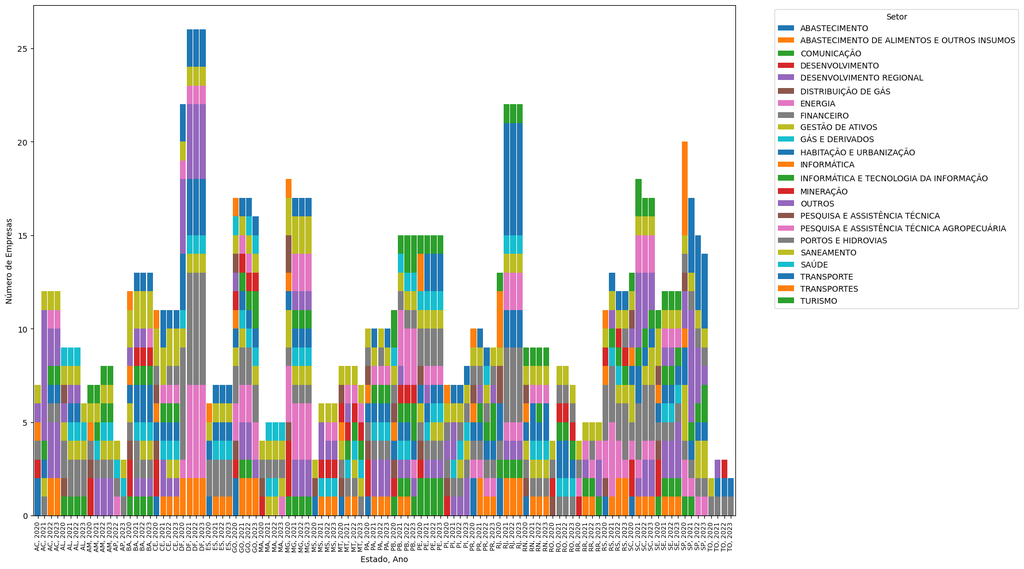

```python
df = pd.read_csv(file_path)
# Filtrar os estados para garantir que todos estão sendo incluídos
df_filtrado = df[df["Estado"].notna()]

# Agrupar por estado, ano e setor para contar as empresas
agrupado = df_filtrado.groupby(["Estado", "Ano", "setor"]).size().unstack(fill_value=0)

# Ajustar os índices para adicionar mais espaçamento (concatenando Estado e Ano)
x_labels = ["{}, {}".format(estado, ano) for estado, ano in agrupado.index]
x = np.arange(len(x_labels))

# Plotar gráfico de barras empilhadas com maior espaçamento
fig, ax = plt.subplots(figsize=(18, 10))  # Aumentando o tamanho da figura
width = 0.9  # Largura das barras, para aumentar o espaçamento entre elas

agrupado.plot(kind="bar", stacked=True, ax=ax, width=width)

# Ajustar os rótulos do eixo X para que haja mais espaçamento e garantir que fiquem visíveis
ax.set_xticks(x)
ax.set_xticklabels(
    x_labels, rotation=90, ha="center", fontsize=8
)  # Rotacionando os rótulos

# Definir título e rótulos
plt.title("")
plt.xlabel("Estado, Ano")
plt.ylabel("Número de Empresas")

# Ajustar a posição da legenda e o layout para evitar sobreposição
plt.legend(title="Setor", bbox_to_anchor=(1.05, 1), loc="upper left")
plt.tight_layout()
plt.show()
```

#### Resultado Líquido das Empresas para o Estado Acionista por Estado e por ano

O gráfico demonstra o desempenho financeiro das empresas estatais para seus respectivos estados acionistas, distribuído por ano e estado, evidenciando uma discrepância significativa entre lucros e prejuízos ao longo do período analisado. A análise revela que, enquanto alguns estados conseguem gerar resultados positivos consistentes por meio de suas empresas públicas, outros enfrentam déficits expressivos que impactam negativamente suas finanças públicas. A variação observada reflete não apenas a natureza e gestão das empresas estatais em cada estado, mas também as condições econômicas regionais e as políticas públicas adotadas.

O gráfico também evidencia períodos de deterioração financeira generalizada, especialmente em anos marcados por crises econômicas, como 2020, que refletiram os impactos da pandemia de COVID-19. Nesse período, a maioria dos estados registrou resultados líquidos negativos, indicando os desafios enfrentados pelas empresas estatais em manter suas operações durante um contexto de retração econômica e aumento de custos. A análise global do gráfico reforça a importância de estratégias diferenciadas e adaptações estruturais, tanto para melhorar os desempenhos financeiros quanto para garantir a sustentabilidade das empresas públicas em estados com desafios fiscais mais agudos.

```python
df = pd.read_csv(file_path)
# Certifique-se de que os valores de 'Resultado para o Estado Acionista' sejam numéricos
df_filtrado["Resultado para o Estado Acionista"] = pd.to_numeric(
    df_filtrado["Resultado para o Estado Acionista"], errors="coerce"
)

# Agrupar por Estado e Ano para somar o Resultado Líquido para o Estado Acionista
agrupado_resultado = (
    df_filtrado.groupby(["Estado", "Ano"])["Resultado para o Estado Acionista"]
    .sum()
    .reset_index()
)

# Determinar as cores com base se o valor é positivo ou negativo
agrupado_resultado["color"] = agrupado_resultado[
    "Resultado para o Estado Acionista"
].apply(lambda x: "#007acc" if x > 0 else "#F46045")

# Criar gráfico de barras interativo com Plotly
fig = go.Figure()

# Adicionar barras ao gráfico
for i, row in agrupado_resultado.iterrows():
    fig.add_trace(
        go.Bar(
            x=[f"{row['Estado']}, {row['Ano']}"],
            y=[row["Resultado para o Estado Acionista"]],
            name=f"{row['Estado']}, {row['Ano']}",
            hoverinfo="text",
            textposition="none",
            hovertext=f"Estado: {row['Estado']}<br>Ano: {row['Ano']}<br>Valor: R${row['Resultado para o Estado Acionista']:,.2f}",
            marker_color=row["color"],
        )
    )

# Atualizar layout do gráfico
fig.update_layout(
    title="",
    xaxis_title="Estado, Ano",
    yaxis_title="Resultado Líquido para o Estado (R$)",
    yaxis=dict(
        range=[
            -7_000_000_000,
            agrupado_resultado["Resultado para o Estado Acionista"].max() + 200_000_000,
        ]
    ),
    xaxis=dict(
        tickangle=-90,  # Girar rótulos para melhor visualização
        tickfont=dict(size=10),  # Diminuir o tamanho da fonte para melhor ajuste
    ),
    showlegend=False,
    template="plotly_white",
    height=1000,  # Aumenta a altura do gráfico
    width=1600,  # Aumenta a largura do gráfico
    margin=dict(l=40, r=100, t=40, b=150),  # Aumenta a margem direita
)

# Mostrar o gráfico
fig.show()
```

#### Resultado Líquido das Empresas para o Estado Acionista por Estado, por ano e por setor

O gráfico apresenta uma visão detalhada do resultado líquido das empresas estatais brasileiras, analisado por estado, ano e setor de atuação. Essa segmentação permite identificar padrões setoriais de desempenho e tendências financeiras que variam significativamente entre regiões e períodos, evidenciando tanto as potencialidades quanto os desafios enfrentados pelos estados no gerenciamento de suas estatais.

Adicionalmente, observa-se uma correlação entre os resultados líquidos negativos e a predominância de empresas em setores que atendem a demandas sociais essenciais. Empresas de saneamento, saúde e transporte, embora deficitárias em muitos casos, desempenham papéis críticos no cumprimento de políticas públicas e no atendimento à população. Isso reforça a necessidade de um equilíbrio entre eficiência financeira e impacto social, principalmente em estados com restrições fiscais mais severas.

Por fim, a análise segmentada por setor ao longo dos anos destaca a importância da diversificação econômica e do fortalecimento da governança corporativa nas estatais. Estados que priorizam investimentos em setores de alta rentabilidade, como energia e financeiro, apresentam maior resiliência fiscal, enquanto estados mais dependentes de setores deficitários precisam buscar soluções estratégicas, como reestruturação de empresas, ampliação de parcerias público-privadas e modernização tecnológica. Esses ajustes são cruciais para garantir a sustentabilidade financeira e o impacto positivo das estatais no desenvolvimento econômico e social de suas respectivas regiões.

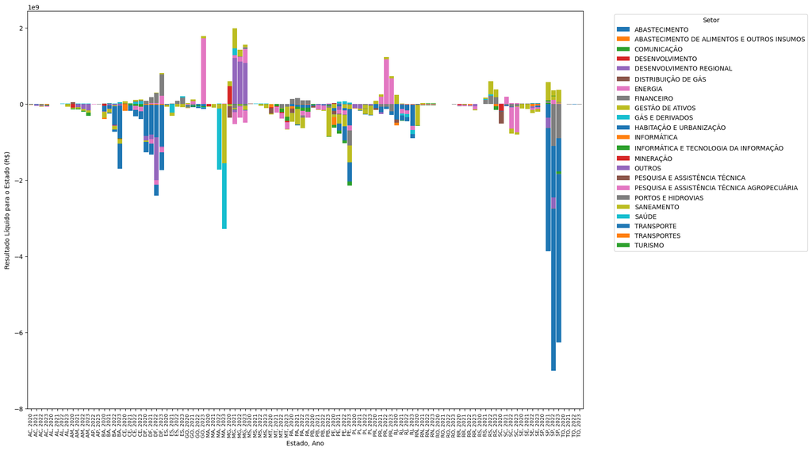

```python
df = pd.read_csv(file_path)
# Certifique-se de que os valores de 'Resultado para o Estado Acionista' sejam numéricos
df_filtrado["Resultado para o Estado Acionista"] = pd.to_numeric(
    df_filtrado["Resultado para o Estado Acionista"], errors="coerce"
)

# Agrupar por Estado, Ano e Setor para somar o Resultado Líquido para o Estado Acionista
agrupado_resultado = (
    df_filtrado.groupby(["Estado", "Ano", "setor"])["Resultado para o Estado Acionista"]
    .sum()
    .unstack(fill_value=0)
)

# Ajustar os índices para adicionar mais espaçamento (concatenando Estado e Ano)
x_labels = ["{}, {}".format(estado, ano) for estado, ano in agrupado_resultado.index]
x = np.arange(len(x_labels))

# Plotar gráfico de barras empilhadas com maior espaçamento
fig, ax = plt.subplots(figsize=(18, 10))  # Aumentando o tamanho da figura
width = 0.9  # Largura das barras para maior espaçamento

agrupado_resultado.plot(kind="bar", stacked=True, ax=ax, width=width)

# Ajustar os rótulos do eixo X para que haja mais espaçamento e garantir que fiquem visíveis
ax.set_xticks(x)
ax.set_xticklabels(
    x_labels, rotation=90, ha="center", fontsize=8
)  # Rotacionando os rótulos

# Definir o limite inferior do eixo y para R$ -20 bilhões
ax.set_ylim(bottom=-8_000_000_000)  # Adiciona esta linha

# Definir título e rótulos
plt.title("")
plt.xlabel("Estado, Ano")
plt.ylabel("Resultado Líquido para o Estado (R$)")

# Ajustar a posição da legenda e o layout para evitar sobreposição
plt.legend(title="Setor", bbox_to_anchor=(1.05, 1), loc="upper left")
plt.tight_layout()
plt.show()
```

#### Resultado Líquido das Empresas para o Estado Acionista por Estado, por ano e por dependência

O gráfico analisa o resultado líquido das empresas estatais por estado, ano e classificação de dependência (dependente, não dependente ou não informado), evidenciando as disparidades de desempenho financeiro das empresas em relação ao suporte recebido de seus respectivos estados acionistas. A segmentação entre empresas dependentes e não dependentes fornece uma visão clara sobre a influência da autonomia financeira na sustentabilidade das estatais.

O gráfico também destaca um padrão ao longo do tempo: anos de crises econômicas, como 2020, apresentam déficits mais acentuados, especialmente entre empresas dependentes, devido ao aumento dos custos operacionais e à redução das receitas próprias. Por outro lado, os resultados das empresas não dependentes mostram maior estabilidade e resiliência em momentos de instabilidade econômica, refletindo modelos de negócios mais robustos.

A presença de uma categoria de dados não informados, indicada em cinza, levanta a necessidade de maior transparência nos relatórios financeiros das estatais. A falta de clareza na classificação de dependência pode dificultar análises mais precisas e a formulação de estratégias para melhorar a sustentabilidade financeira das empresas públicas. No geral, o gráfico reforça a importância de fortalecer a governança corporativa, promover a eficiência operacional e buscar alternativas estratégicas, como parcerias público-privadas, especialmente para empresas deficitárias.

```python
df = pd.read_csv(file_path)
# Certifique-se de que os valores de 'Resultado para o Estado Acionista' sejam numéricos
df_filtrado["Resultado para o Estado Acionista"] = pd.to_numeric(
    df_filtrado["Resultado para o Estado Acionista"], errors="coerce"
)

# Agrupar por Estado, Ano e 'dep' para somar o Resultado Líquido para o Estado Acionista
agrupado_resultado = (
    df_filtrado.groupby(["Estado", "Ano", "dep"])["Resultado para o Estado Acionista"]
    .sum()
    .reset_index()
)

# Juntar Estado e Ano para usar como rótulo
agrupado_resultado["label"] = (
    agrupado_resultado["Estado"] + ", " + agrupado_resultado["Ano"].astype(str)
)

# Ordenar o DataFrame com base nos rótulos alfabéticos
agrupado_resultado.sort_values("label", inplace=True)

# Definir as cores específicas para cada categoria
color_map = {
    "Não Dependente": "#007acc",
    "Dependente": "#F46045",
    "Não Informado": "rgba(150, 150, 150, 0.8)",
}

# Criar gráfico de barras interativo com Plotly
fig = go.Figure()

# Loop sobre cada 'dep' distinto e adicionar como uma série no gráfico
for categoria, color in color_map.items():
    df_categoria = agrupado_resultado[agrupado_resultado["dep"] == categoria]
    fig.add_trace(
        go.Bar(
            x=df_categoria["label"],
            y=df_categoria["Resultado para o Estado Acionista"],
            name=categoria,
            hoverinfo="text",
            textposition="none",
            hovertext=df_categoria.apply(
                lambda row: f"Estado: {row['Estado']}<br>Ano: {row['Ano']}<br>Departamento: {row['dep']}<br>Valor: R${row['Resultado para o Estado Acionista']:,.2f}",
                axis=1,
            ),
            marker_color=color,
        )
    )

# Atualizar layout do gráfico
fig.update_layout(
    title="",
    xaxis_title="Estado, Ano",
    yaxis_title="Resultado Líquido para o Estado (R$)",
    barmode="stack",
    yaxis=dict(
        range=[
            -7_000_000_000,
            agrupado_resultado["Resultado para o Estado Acionista"].max() + 200_000_000,
        ]
    ),
    xaxis=dict(
        categoryorder="array",
        categoryarray=sorted(
            agrupado_resultado["label"].unique()
        ),  # Reordena alfabeticamente
        tickangle=-90,
        tickfont=dict(size=10),
    ),
    showlegend=True,
    template="plotly_white",
    height=1000,
    width=1600,
    margin=dict(l=40, r=200, t=40, b=150),
)

# Mostrar o gráfico
fig.show()
```

# Exportação do arquivo

```python
# Converter o Notebook para HTML
!jupyter nbconvert --to html --ExecutePreprocessor.enabled=True "C:\Users\Eric\OneDrive\Estudos\RBCIP\Estatais\Dashboard\Arquivos VS Code\Painel Estatais.ipynb"
```

```
[NbConvertApp] Converting notebook C:\Users\Eric\OneDrive\Estudos\RBCIP\Estatais\Dashboard\Arquivos VS Code\Painel Estatais.ipynb to html
[NbConvertApp] WARNING | Alternative text is missing on 10 image(s).
[NbConvertApp] Writing 1281820 bytes to C:\Users\Eric\OneDrive\Estudos\RBCIP\Estatais\Dashboard\Arquivos VS Code\Painel Estatais.html
```

```python
# Converter o Notebook para HTML
!jupyter nbconvert --to html "C:\Users\Eric\OneDrive\Estudos\RBCIP\Estatais\Dashboard\Arquivos VS Code\Painel Estatais.ipynb"
```

import os

# Caminho do arquivo original e o novo nome

# Renomear o arquivo

os.rename(original_path, new_path)